# 함수추정 및 실습 PROJECT

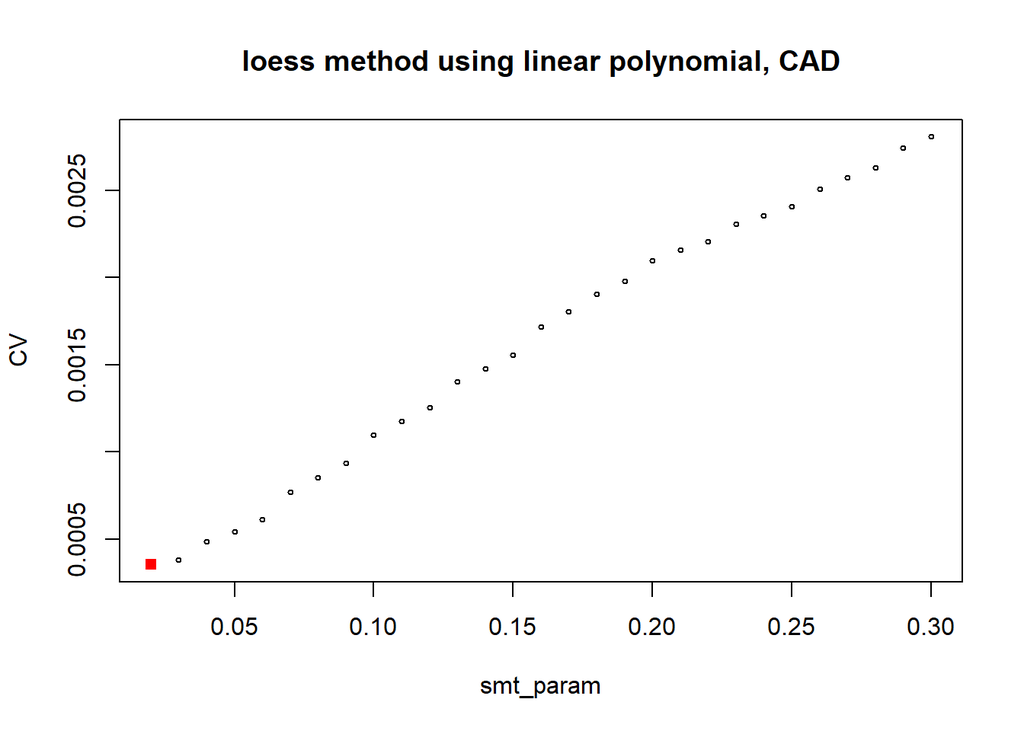

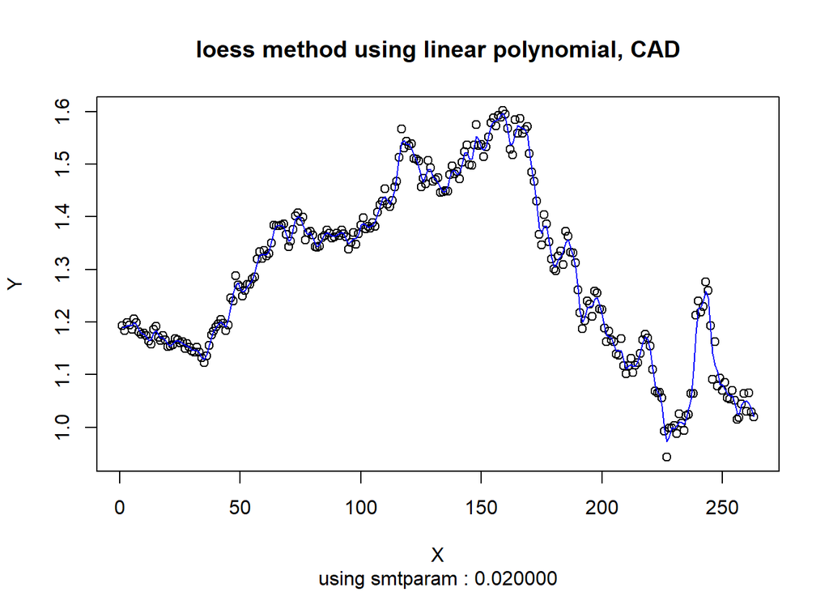

```
## [1] 0.0001160333
```

```r
full_test(estimate_loess_linear, data$X, data$CAD, seq(from = 0.02, to = 0.3, by = 0.01), description = "loess method using linear polynomial, CAD")
```

다음은, 2차 함수를 사용했을 경우이다. 역시, span이 너무 작으면 estimate를 하는데 사용할 데이터 포인트의 개수가 너무 작아지므로, 0.03~0.3까지, 0.01간격으로 span을 넣고 실험해보았다.

```r
rss_GBP[5] <- full_test(estimate_loess_quad, data$X, data$GBP, seq(from = 0.03, to = 0.3, by = 0.01), description = "loess method using quadratic polynomial, GBP")
```

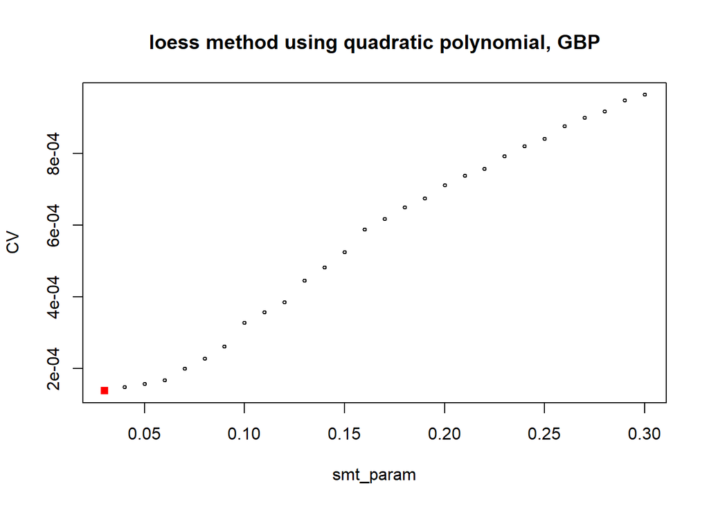

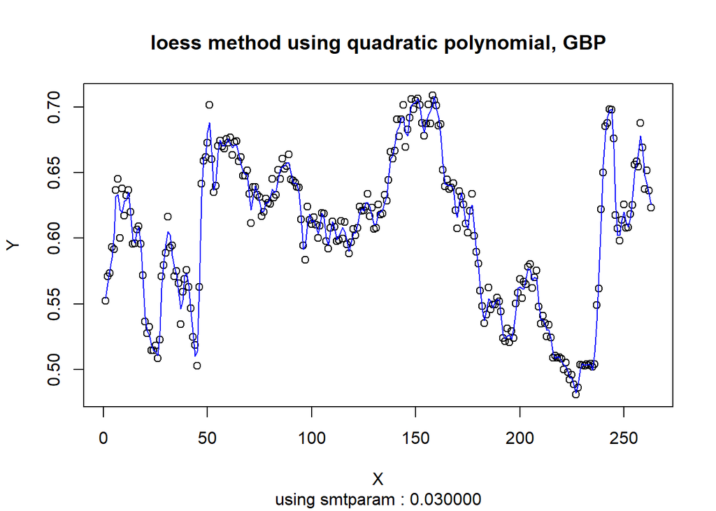

```r
rss_CHF[5] <- full_test(estimate_loess_quad, data$X, data$CHF, seq(from = 0.03, to = 0.3, by = 0.01), description = "loess method using quadratic polynomial, CHF")
```

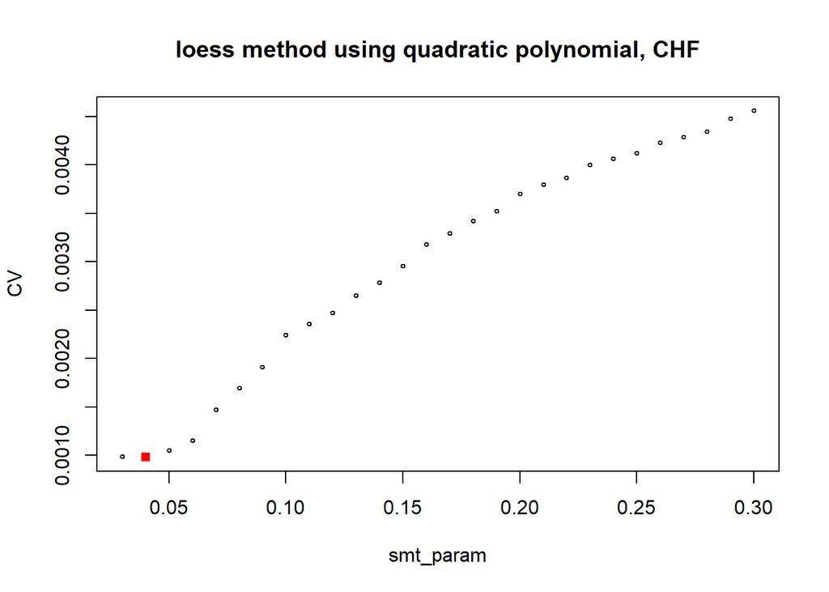

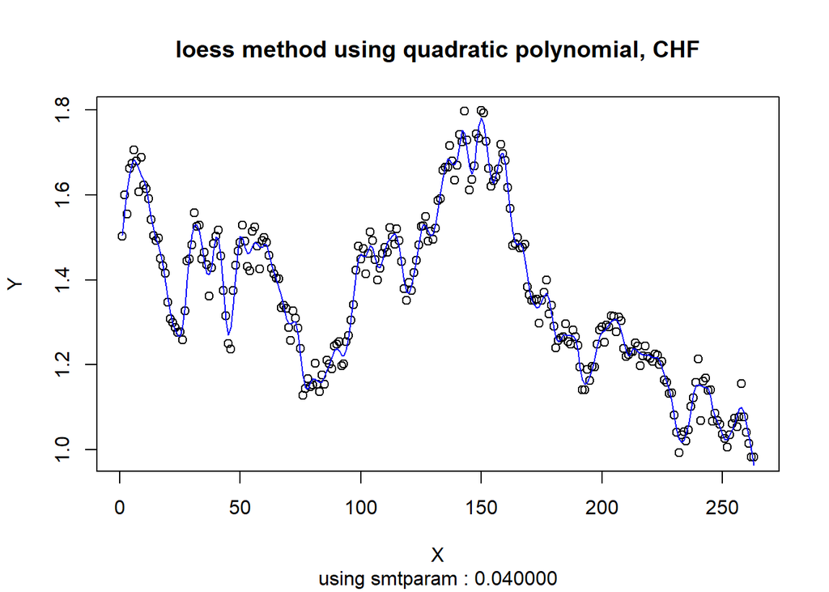

```r
rss_CAD[5] <- full_test(estimate_loess_quad, data$X, data$CAD, seq(from = 0.03, to = 0.3, by = 0.01), description = "loess method using quadratic polynomial, CAD")
```

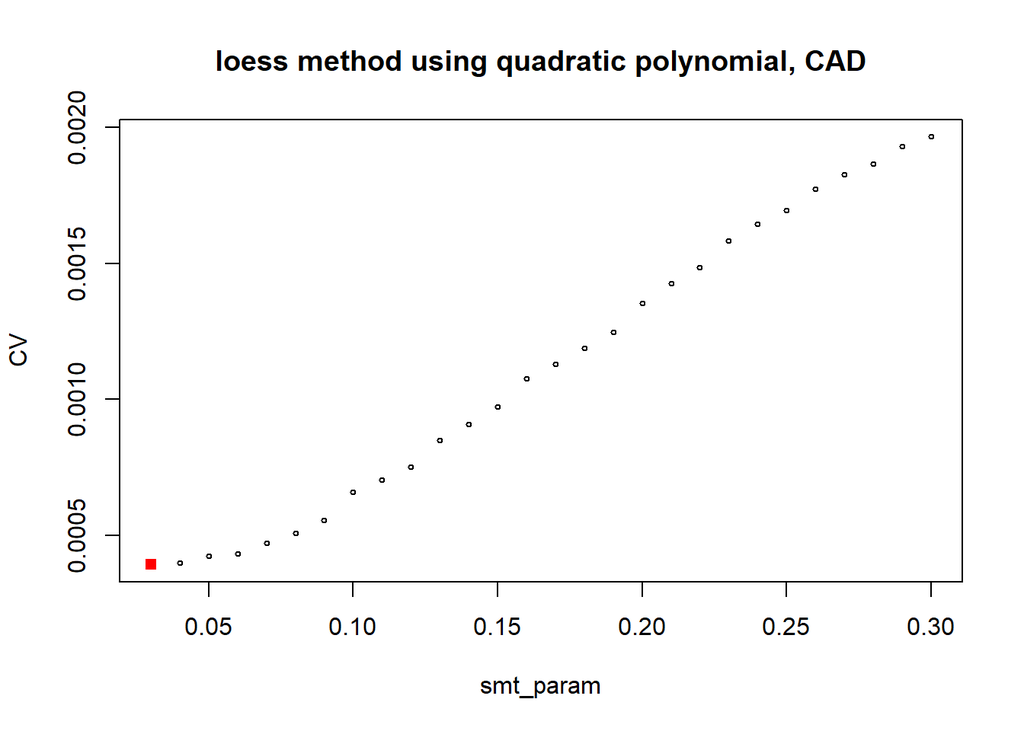

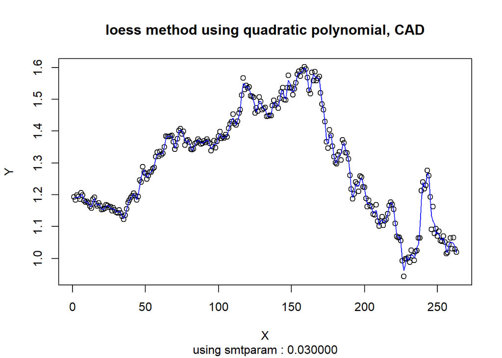

### supersmoother

super smoother의 알고리즘을 생각해보면, k값으로 0.05n, 0.2n, 0.5n의 값을 사용하고, 1차 polynomial LOESS를 span = k/n의 값으로 각 k에 대해 진행한 다음,

$$r_{(i)}(k) = \frac{Y_i - \widehat{m}_k(X_i)}{1 - h_{ii}}$$

(여기서 $h_{ii}$는 local linear regression의 hat matrix에서 얻어짐)

위 residual의 크기를 최소화하는 k를 이용하여 $X_i$에서의 값을 추정한다음,

그 추정 값을 $k^(*)(X_i)$라 할때,

이 추정값들을 이용해서 $k_2 = 0.2n$을 이용하여 다시 smoothing이 된 결과를 최종 추정값으로 내놓게 된다.

이러한 과정은 R의 supsmu 함수를 이용하여 가능하다.

supsmu함수는 span인자를 지정하지 않으면 위와 같은 알고리즘으로 smoothing을 하게 되고, span 인자를 지정해주면 span에 해당하는 single smoother만 사용해서 smoothing을 하게 된다.

이때, 유의할점은, supsmu는 주어진 datapoint에서만의 값을 리턴할 수 있고, 따라서 주어진 datapoint 바깥에서의 prediction은 불가능하다.

따라서, 지금까지와 달리 estim_x 가 NULL일때만 작동해야한다.

span인자에 따라 다음과 같은 두가지의 버전을 만들자.

```r
estimate_super_smoother_default <- function(xdata, ydata, sp = 0, estim_x = NULL)
{
    fit.su <- supsmu(xdata, ydata, span = "cv")

    if(is.null(estim_x))
    {
        ey <- fit.su$y
    }
    else
    {
        stop("super smoother can't predict!")
    }
    return(ey)
}


estimate_super_smoother <- function(xdata, ydata, sp, estim_x = NULL)
{
    fit.su <- supsmu(xdata, ydata, span = sp)

    if(is.null(estim_x))
    {
        ey <- fit.su$y
    }
    else
    {
        stop("super smoother can't predict!")
    }
    return(ey)
}
```

이제, 위 함수를 이용해서 test를 진행할 수 있다.

default값을 사용한 케이스와, 그렇지 않은 케이스에 대해 각각 test를 진행해보자.

```r
rss_GBP[6] <- full_test(estimate_super_smoother_default, data$X, data$GBP, c(0), description = "supersmoother method using default span, GBP")
```

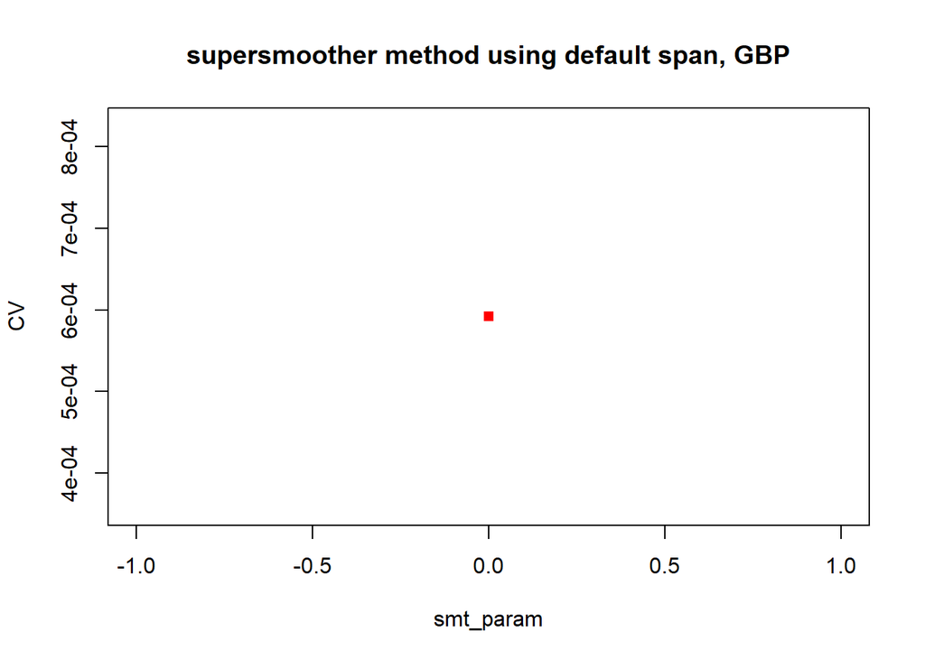

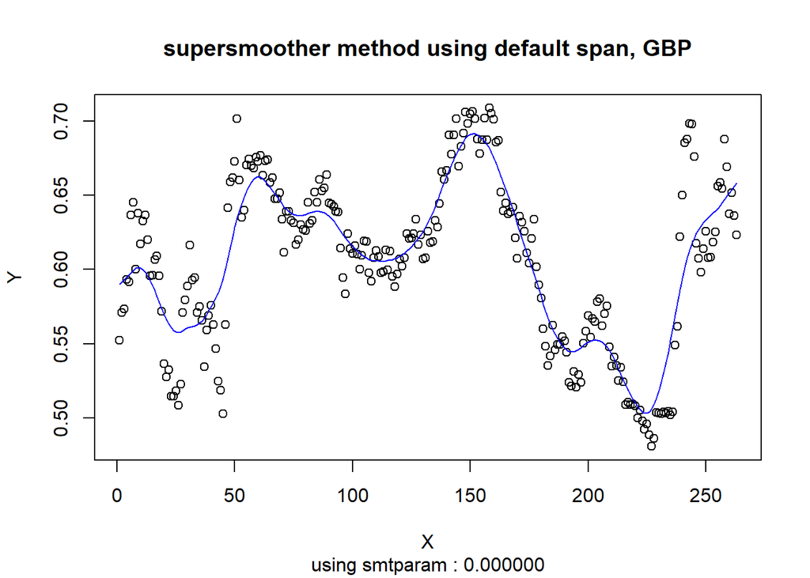

```r
rss_CHF[6] <- full_test(estimate_super_smoother_default, data$X, data$CHF, c(0), description = "supersmoother method using default span, CHF")
```

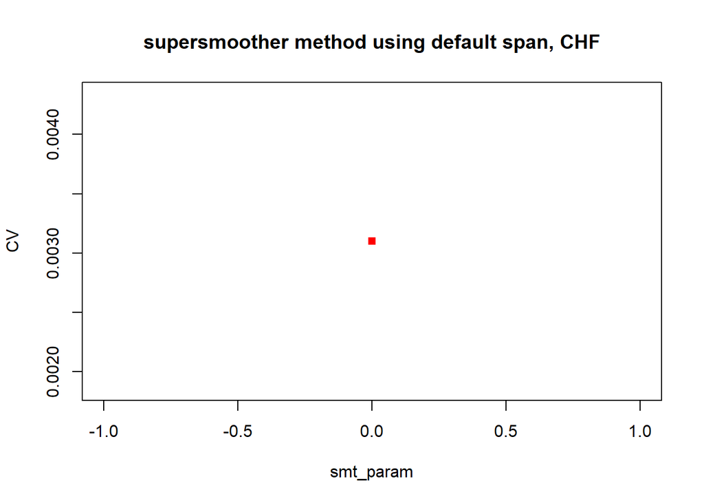

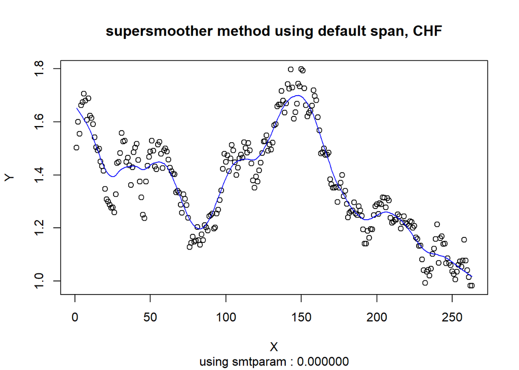

```r
rss_CAD[6] <- full_test(estimate_super_smoother_default, data$X, data$CAD, c(0), description = "supersmoother method using default span, CAD")
```

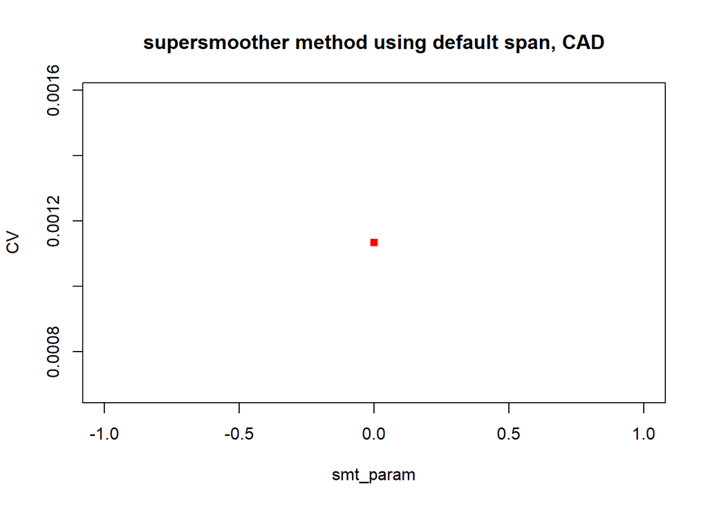

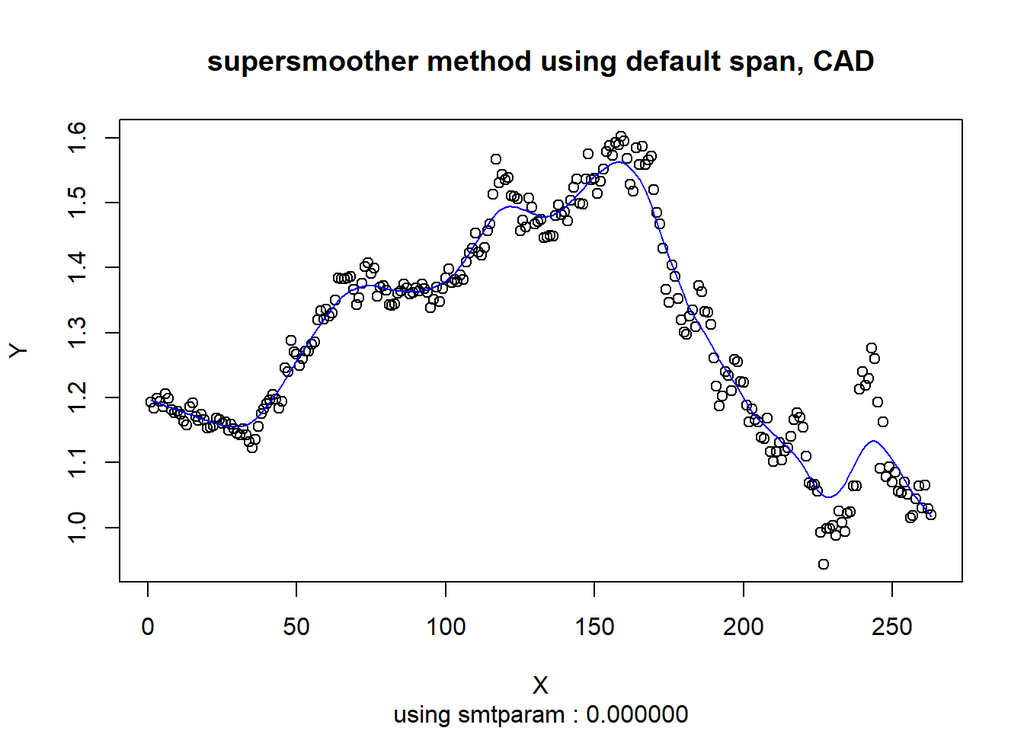

결과는 위와 같다.

이제, span의 값으로 0.02~0.3까지, 0.01간격을 두고 실행하여 test를 진행해보자.

```r
rss_GBP[7] <- full_test(estimate_super_smoother, data$X, data$GBP, seq(from = 0.02, to = 0.3, by = 0.01), description = "supersmoother method using custom span, GBP")
```

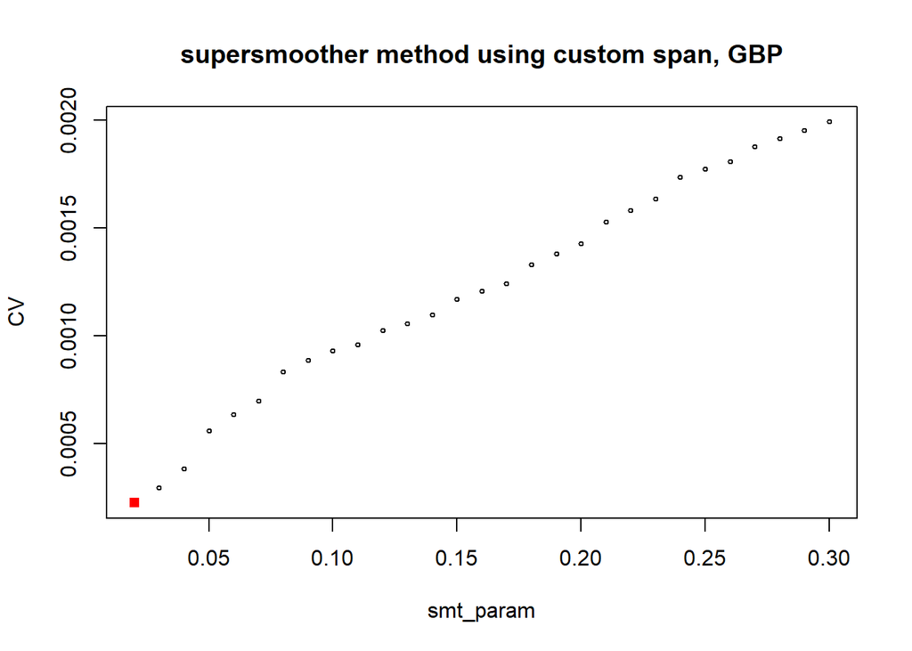

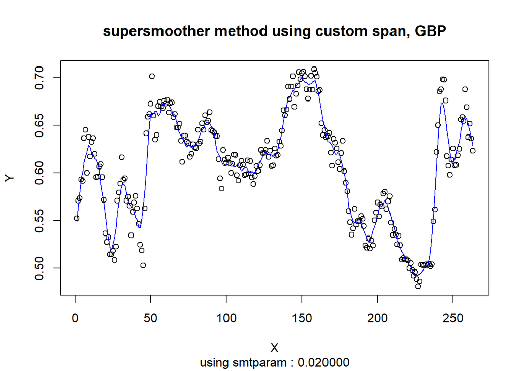

```r
rss_CHF[7] <- full_test(estimate_super_smoother, data$X, data$CHF, seq(from = 0.02, to = 0.3, by = 0.01), description = "supersmoother method using custom span, CHF")
```

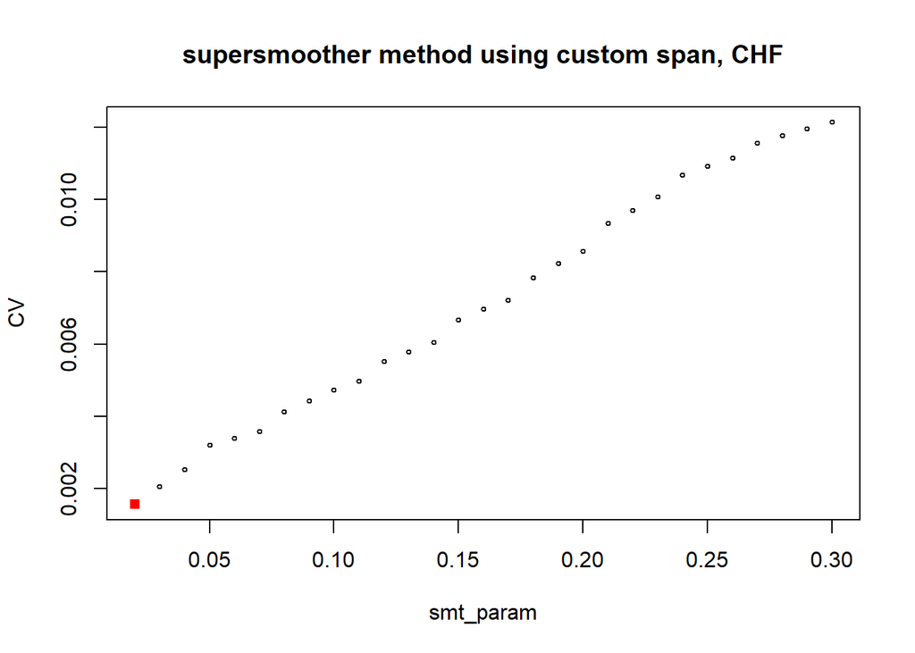

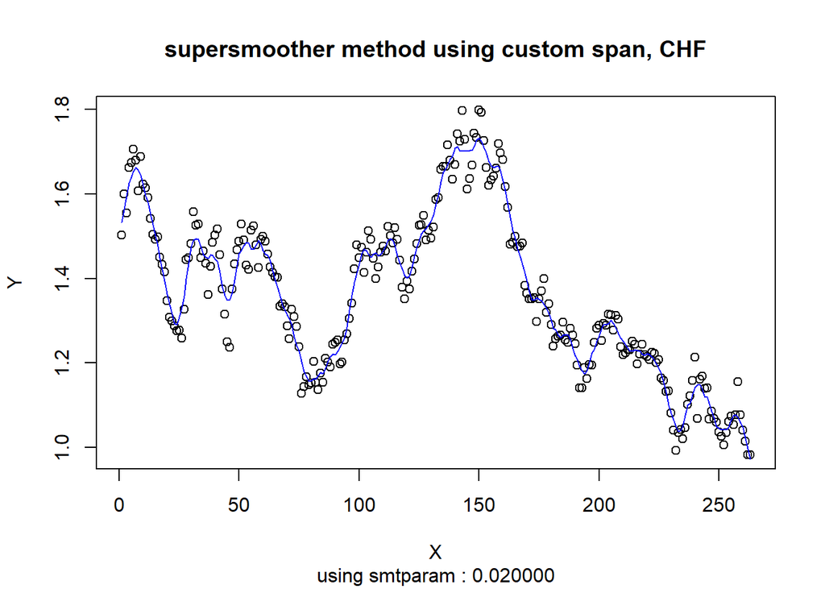

```r
rss_CAD[7] <- full_test(estimate_super_smoother, data$X, data$CAD, seq(from = 0.02, to = 0.3, by = 0.01), description = "supersmoother method using custom span, CAD")
```

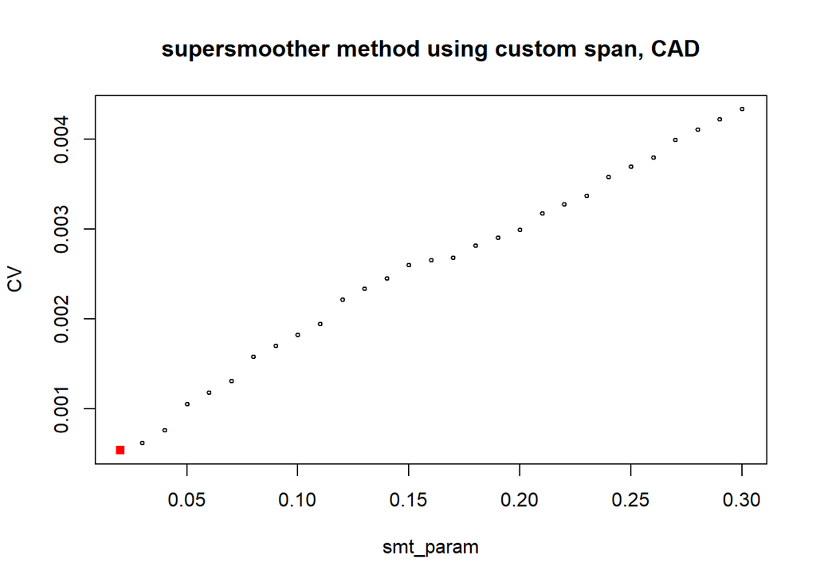

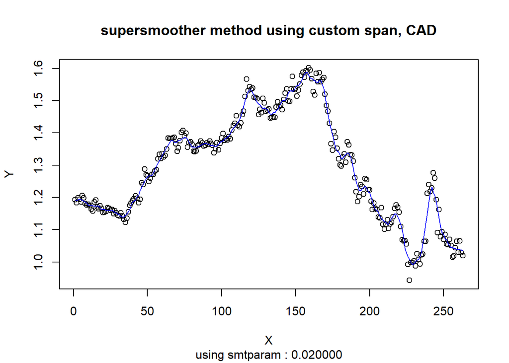

결과는 위와 같다.

### LOWESS

LOWESS는 LOESS의 개선된 버전으로, LOESS에서 outlier가 있을때 생기는 문제를 해결하기 위해 제안되었다.

즉, LOESS의 robust버전으로, 다음과 같은 알고리즘을 사용하여 smoothing을 진행한다.

1. LOESS를 일단 해서, $\hat{Y_i}$들을 구한다. 그리고, residual들을 계산한다. $r_i = Y_i - \hat{Y_i}$
2. robustness weight $\{\sigma_i = B(r_i/(6\hat{s})\}$를 구한다. 이때, $B(u)$는 bisquare weight function이고, $\hat{s} = med(\{r_i\})$가 된다.
3. LOESS에서, weight를 $\sigma_i w(\frac{X_i - x^*}{h_k(x^*)})$ 로 바꿔서 진행한다음, residual을 다시 구한다.
4. 2,3을 3번 더 반복한다.

R에서 LOWESS는 lowess 함수를 이용하면 가능하고,

이 함수 역시 prediction을 하는 기능은 제공하지 않으므로

supersmoother를 구현할때와 같이 estim_x를 사용하는 기능은 막아놓을것이다.

```r
estimate_lowess <- function(xdata, ydata, sp, estim_x = NULL)
{
    fit.low <- lowess(xdata, ydata, f = sp)

    if(is.null(estim_x))
    {
        ey <- fit.low$y
    }
    else
    {
        stop("lowess can't predict!")
    }
    return(ey)
}
```

위와 같이 estimate_function을 구현한다.

이제, 위 함수를 이용해서 test를 진행할 수 있다.

span의 값으로 0.02~0.3까지, 0.01간격을 두고 실행하여 test를 진행해보자.

```r
rss_GBP[8] <- full_test(estimate_lowess, data$X, data$GBP, seq(from = 0.02, to = 0.3, by = 0.01), description = "lowess method, GBP")
```

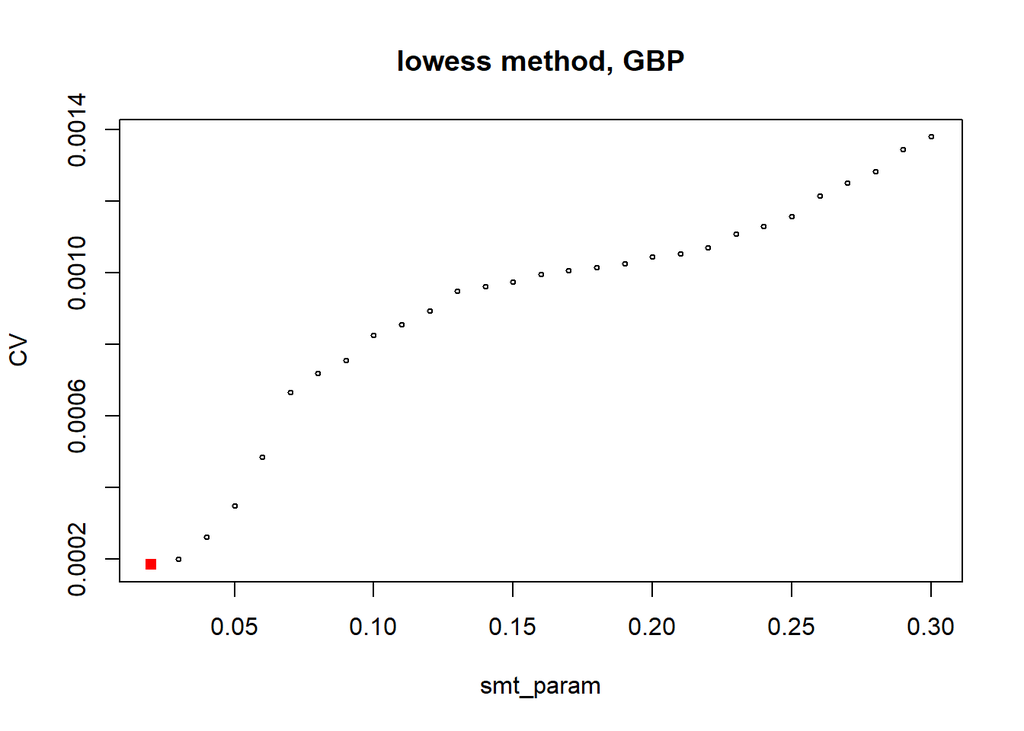

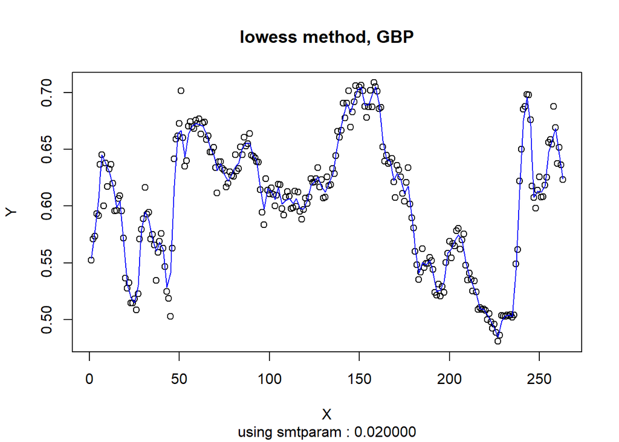

```r
rss_CHF[8] <- full_test(estimate_lowess, data$X, data$CHF, seq(from = 0.02, to = 0.3, by = 0.01), description = "lowess method, CHF")
```

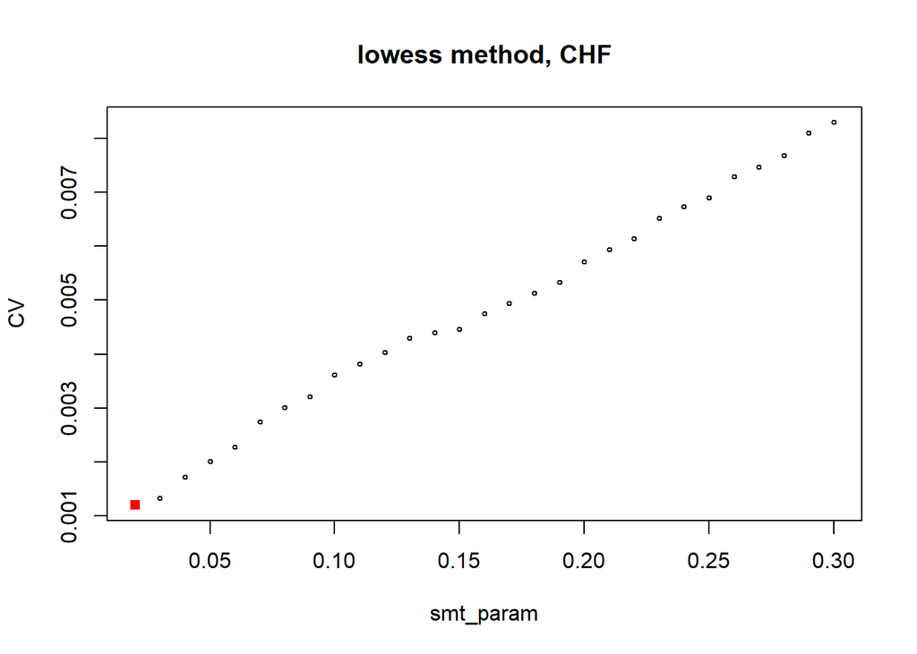

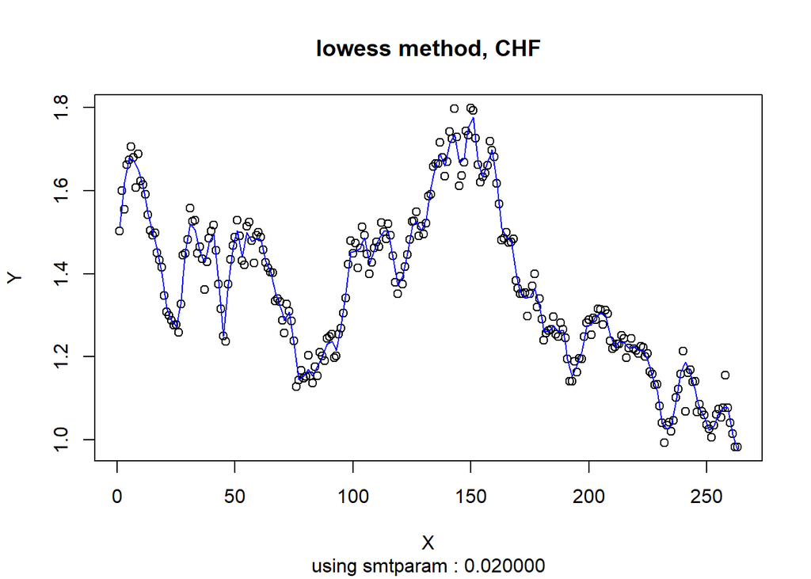

```r
rss_CAD[8] <- full_test(estimate_lowess, data$X, data$CAD, seq(from = 0.02, to = 0.3, by = 0.01), description = "lowess method, CAD")
```

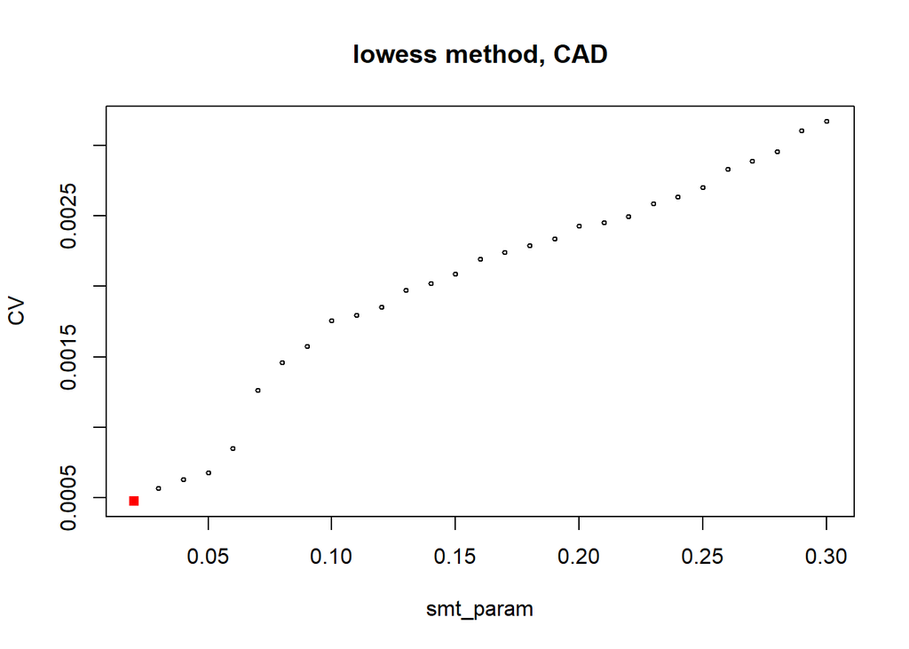

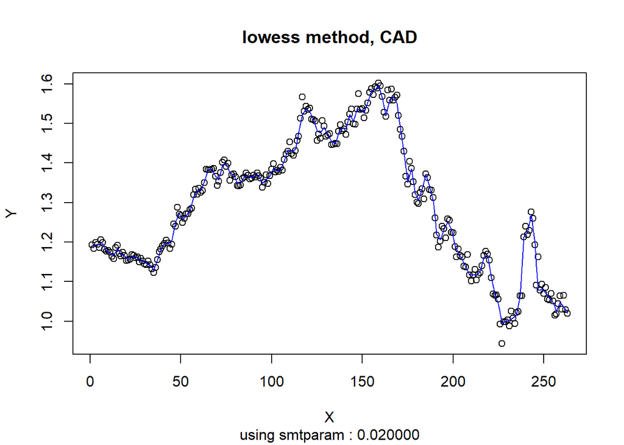

이제, 가장 좋은 method를 찾기위해 앞에서 만든 rss 벡터들의 값중 어떤 값이 가장 작은지를 볼것이다.

```r
which(rss_GBP == min(rss_GBP, na.rm = TRUE))
```

```
## [1] 1
```

```r
which(rss_CHF == min(rss_CHF, na.rm = TRUE))
```

```
## [1] 2
```

```r
which(rss_CAD == min(rss_CAD, na.rm = TRUE))
```

```
## [1] 1
```

각각 GBP, CHF, CAD에 대해 어떤것이 best method인지를 위와 같이 알아볼 수 있었다.

## Q2

지금까지의 경향을 살펴보면, 대부분의 경우 smoothing parameter의 값을 가능한 한 작게 유지했을때 cross validation값이 작게 유지됨을 알 수 있다. 이는, cross validation의 경우 전체 dataset $D = (X_i, Y_i)_{i=1,2...n}$에서 하나의 데이터만 제외한 데이터를 이용해서 ($D^{-k} = (X_i, Y_i)_{i \neq k}$), 제외한 데이터의 자리에 대한 값을 추정했을때의 값이 최대한 원래 데이터의 값과 비슷할때에 앞에서 구한 cross validation의 값이 작아지게 된다.
$$C V[\hat{m}(x)]=\frac{\sum_{k=1}^{n}\left(Y_{k}-\hat{m}\left(X_{k}\right)\right)^{2}}{n(1 - H_{ii})^2}$$

하지만, 우리의 데이터는 시계열 데이터이다. 즉, 시간에 따라 연속적으로 변하는 데이터이고, 우리의 데이터는 더군다나 환율이기 때문에 $(X_i, Y_i)$는 이 값 주변의 값들, 즉, 시간대가 비슷한 데이터들과 큰 연관이 있을수밖에 없다.

(예를 들어, 전날 환율이 1달러에 1000원일때와 1달러에 2000원이었을때, 다음날 환율이 1달러에 1050원일 확률은 당연히 전자가 높을수밖에 없다. 즉, 시간적으로 인접한 데이터에 영향을 받으므로, 독립 가정이 불가능하다.)

따라서 앞에서처럼 leave-one-out cross validation을 한다고 하더라도, data point의 개수가 대략 250개정도나 되고, 제외된 데이터의 주변 데이터는 제외된 데이터와 비슷한 값을 가지고 있을 것이므로, smoothing parameter를 매우 작게해도 비슷한 값을 추정할 수 있을것이고, 따라서 leave-one-out cross validation을 통해 best smoothing parameter를 구하는 방법은 그렇게 좋은 방법이라고 할 수 없다.

왜냐하면 smoothing parameter를 더욱 작게 가져갈수록, $Y_i$가 $\hat{m}(X_i)$에 비슷해질것이고, 이에 따라 대부분의 경우 CV의 값이 계속해서 작아질 것이므로, 대부분의 경우 overfit이 발생하고, 따라서 새로운 데이터를 predict하는데는 별로 도움이 되지 않을것이기 때문이다.

따라서 다른 기준을 이용해서 그래프의 prediction power를 측정할 필요가 있다.

결국, 제외한 데이터의 인접한 데이터를 사용하기 때문에 overfit 현상이 발생하는것이 문제가 되므로, 데이터를 하나만 제외하고 cross validation을 구할것이 아니라,

충분히 많은 데이터를 제외하면서 추정을 해보고, 제외된 datapoint에서 추정된 값과, 실제 데이터 값을 이용하여 cross validation 값을 구할것이다.

즉, 전체 데이터를 k개의 그룹으로 나눈 뒤, cross validation을 구하는,

k-fold cross validation을 사용할 것이다.

앞의 leave-one out cross validation은 전체의 그룹을 n개로 나눈, n-fold cross validation이라 할 수 있으므로,

이를 일반화해서 다음과 같이 k-fold cross validation을 구하자. 이 값을 $CVERR_{(k)}$로 정의한다.

$$CVERR_{(k)} = \frac{1}{k} \sum_{j=1}^k CV_j$$
전체의 데이터 $D = (X_i, Y_i)_{1 \le i \le n}$를 k개의 그룹으로 나눠서,

j번째 그룹의 데이터를 제외한 데이터를 $D^{-j} = (X_i, Y_i)_{i \in S - S_j}$ 라 하자.

이때, $S = \{1,2,...n\}$, $\cup_{j=1}^{k} S_j = S$, $S_i \cap S_j = \emptyset, (i \neq j)$ 가 성립한다.

예를들어, 100개의 데이터를 10-fold cross validation 한다고 하면,

$S_1 = \{1,2..10\}, S_2 = \{11,12...20\}... S_{10} = \{91,...100\}$이 될것이다.

$$CV_j = \frac{1}{n_j}\sum_{i \in S_j}(Y_i - \widehat{m^{-j}}(X_i))^2$$
,

$n_j$는 $S_j$의 원소의 개수,

$m^{-j}$는 $D^{-j} = (X_i, Y_i)_{i \in S - S_j}$ 를 사용하여 추정한 함수이다.

이제, 위에서 처럼 xdata, ydata, smoothing parameter를 받아 estimate된 값을 출력하는 함수를 estimate_func라 할때, 이를 이용해서 k-fold CV의 값을 구해주는 함수를 만들것이다.

먼저, 아래는 전체 n개의 데이터를 k개의 집합으로 나눠주는 함수이다.

리턴하는 값은 list로, 각 list에는 $S_j$에 속하는 index들이 담겨있다.

각 집합에는 $[n/k]$혹은 $[n/k] + 1$개의 데이터가 들어간다. $[x]$는 x를 넘지 않는 가장 큰 정수이다.

```r
get_fold_seq <- function(k, n)
{
    remainder <- n %% k
    q <- n %/% k

    start_point = 1

    idx_lst <- list()
    for(i in seq_len(k))
    {
        if(remainder > 0)
        {
            idx_lst[[i]] = seq(from = start_point, by = 1, length = q + 1)
            start_point <- start_point + q + 1
            remainder <- remainder - 1
        }
        else
        {
            idx_lst[[i]] = seq(from = start_point, by = 1, length = q)
            start_point <- start_point + q
        }
    }

    return(idx_lst)
}
```

```r
get_kfold_cross_validation <- function(estimate_func, x1, y1, smtparam_array, k)
{
#   (1)
    get_kfold_cv <- function(smtparam,estimate_func, x1 ,y1, k)
    {
#   (2)
        cv <- 0
        nd <- length(x1)
        idx_lst <- get_fold_seq(k, nd)
        for(i in seq_len(k)) # get CV_(j) and sum to cv
        {
            xdata <- x1[-idx_lst[[i]]]
            ydata <- y1[-idx_lst[[i]]]
            remain_xdata <- x1[idx_lst[[i]]]
            remain_ydata <- y1[idx_lst[[i]]]
            estim_y <- estimate_func(xdata, ydata, smtparam, remain_xdata)
            cv <- cv + sum((remain_ydata - estim_y)**2)/length(remain_xdata)
        }

        cv <- cv / k
#   (7)
        return(cv)
    }
#   (8)
    cvlst <- lapply(as.list(smtparam_array),get_kfold_cv,  estimate_func = estimate_func, x1 = x1, y1 = y1, k = k)
    cvlst <- unlist(cvlst)
    return(cvlst)
}
```

위 함수는, x,y,smoothing parameter를 가지고 추정값을 리턴해주는 estimate_func과, smoothing parameter들 목록, k를 받아 각 smoothing parameter에 해당하는 k-fold cross validation 값들을 리턴해준다.

또한, $\sum_{i = 252}^{263}(Y_i - \hat{Y_i})^2$를 구해주는 함수는 다음과 같다.

```r
get_predict_err <- function(estimate_func, xdata, ydata, smtparam, remain_x, remain_y)
{
    pred_y <- estimate_func(xdata, ydata, smtparam, remain_x)
    # get predicted value using xdata, ydata at remain_x

    res <- sum((pred_y-remain_y)**2)

    return(res)
}
```

또한, 다음은 xdata, ydata를 이용해 추정한 그래프를, remain_x값에 해당하는 위치까지 확장해서 그림을 그려준다.

```r
plot_graph_remain <- function(estimate_func, xdata, ydata, smtparam, remain_x, remain_y , description = "")
{
    whole_x <- c(xdata, remain_x)
    whole_y <- c(ydata, remain_y)
    par(mfrow=c(1,1))
    estimated_y <- estimate_func(xdata, ydata, smtparam, whole_x)

    plot(whole_x, whole_y , xlab = "X", ylab = "Y", type = "p", main = description, sub = sprintf("using smtparam : %f", smtparam))
    lines(whole_x, estimated_y, col = "blue")
}
```

이를 이용해서, 각 data를 이용해서 각 smoothing parameter에 대해 k-fold cross validation 값이 가장 작은 smoothing parameter를 구하고, 그 값에 대해 smoothing을 진행한 결과를 그래프로 plot하고, 마지막으로 $i=252 \sim 263$에 대해 predict error를 출력하는 함수는 다음과 같다.

```r
full_test_kfold <- function(estimate_func, xdata, ydata, smtparam_array, k, description = "", using_CV = TRUE)
{
    remain_x <- xdata[252:263]
    remain_y <- ydata[252:263]
    xdata_excepted <- xdata[1:251]
    ydata_excepted <- ydata[1:251]


    if(using_CV){
        cv_array <- get_kfold_cross_validation(estimate_func, xdata_excepted, ydata_excepted, smtparam_array, k)

        plot_cv(smtparam_array, cv_array, description)

        smt_idx <- which(cv_array == min(cv_array, na.rm = TRUE))
        if(length(smt_idx) > 1)
        {
            smt_idx <- smt_idx[1]
        }
        best_smt <- smtparam_array[smt_idx]
    }
    else
    {
        best_smt <- smtparam_array[1]
    }
    plot_graph_remain(estimate_func, xdata_excepted, ydata_excepted, best_smt, remain_x, remain_y,description = description)

    rss <- get_predict_err(estimate_func, xdata_excepted, ydata_excepted, best_smt, remain_x, remain_y)

    return(rss)
}
```

이제 앞에서 구현했던 함수들을 이용하면,

다음과 같이 지금까지 구현했던 모든 method를 이용해서 (super smoother와 lowess를 제외하고) 간편하게 k-fold test가 가능하다.

모든 경우에 대해 test를 해보고, 가장 prediction error가 낮은 method를 사용하는것이 타당하다고 생각된다.

k-fold cross-validation에서, k로는 10을 사용하도록 하겠다.

이 결과들에서 prediction error는 다음과 같은 벡터에 저장될것이다.

```r
pred_err_GBP <- vector()
pred_err_CHF <- vector()
pred_err_CAD <- vector()
```

먼저, nadaraya-watson method를 사용했을때다.

```r
pred_err_GBP[1] <- full_test_kfold(estimate_nadaraya, data$X, data$GBP, seq(3,10,by = 0.1), k = 10, description = "nadaraya-watson method, GBF")
```

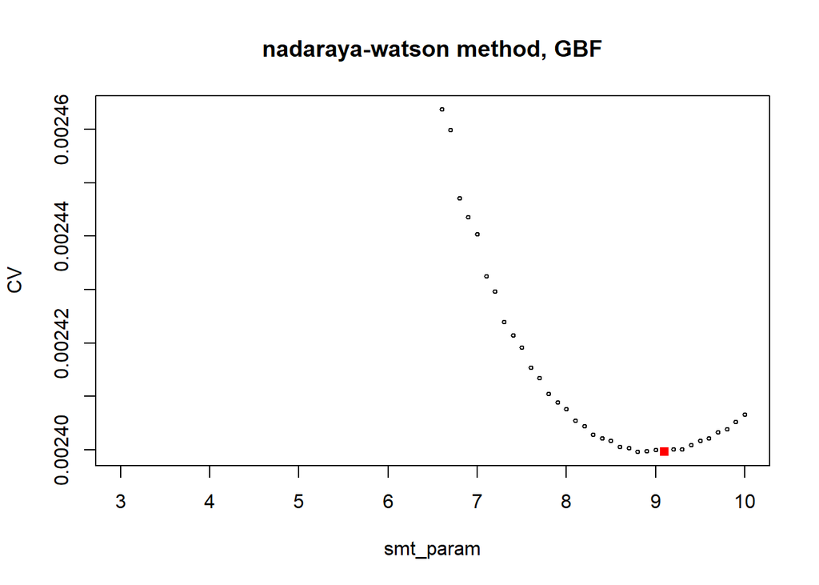

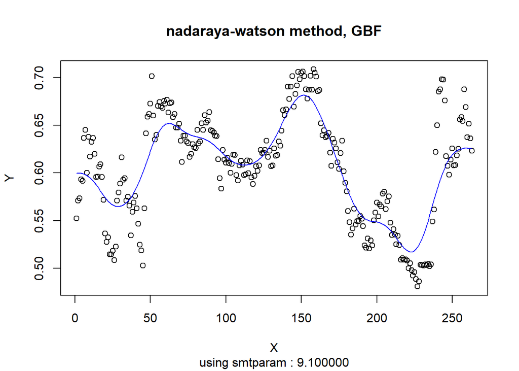

```r
pred_err_CHF[1] <- full_test_kfold(estimate_nadaraya, data$X, data$CHF, seq(3,10,by = 0.1), k = 10, description = "nadaraya-watson method, CHF")
```

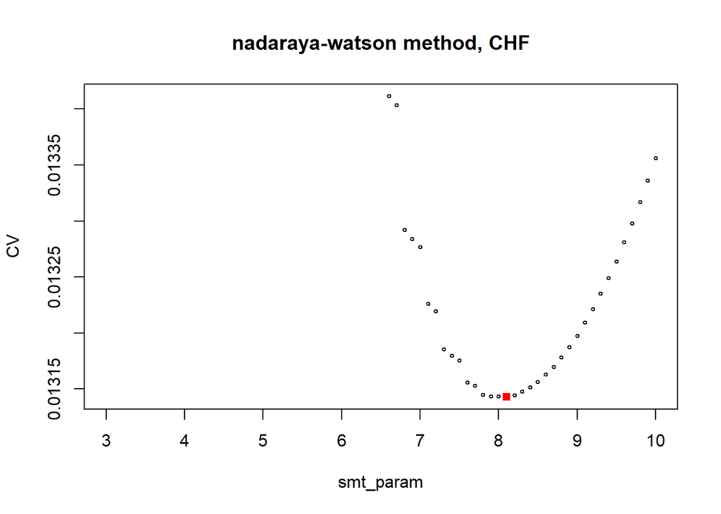

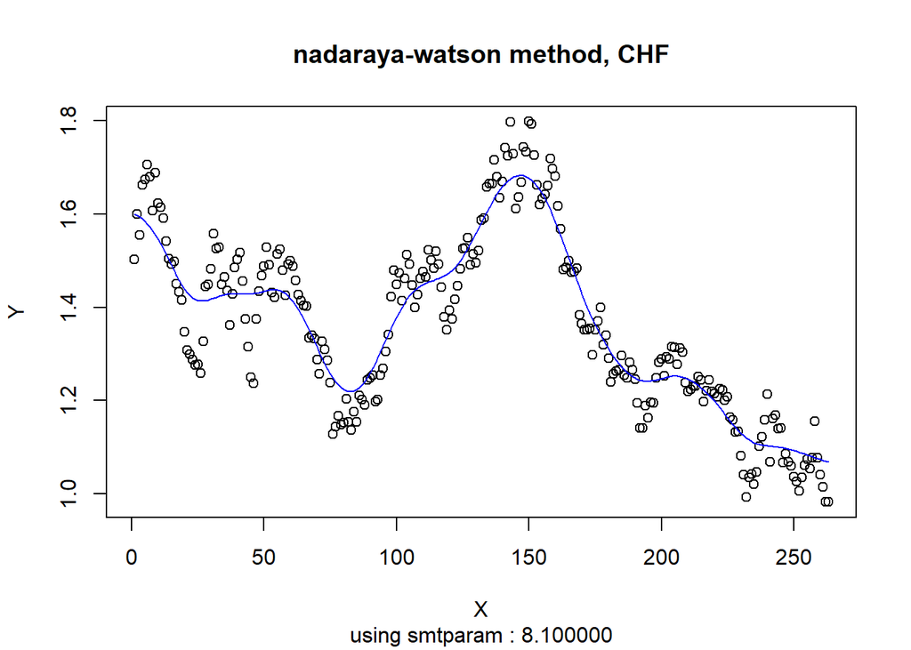

```r
pred_err_CAD[1] <- full_test_kfold(estimate_nadaraya, data$X, data$CAD, seq(3,10,by = 0.1), k = 10, description = "nadaraya-watson method, CAD")
```

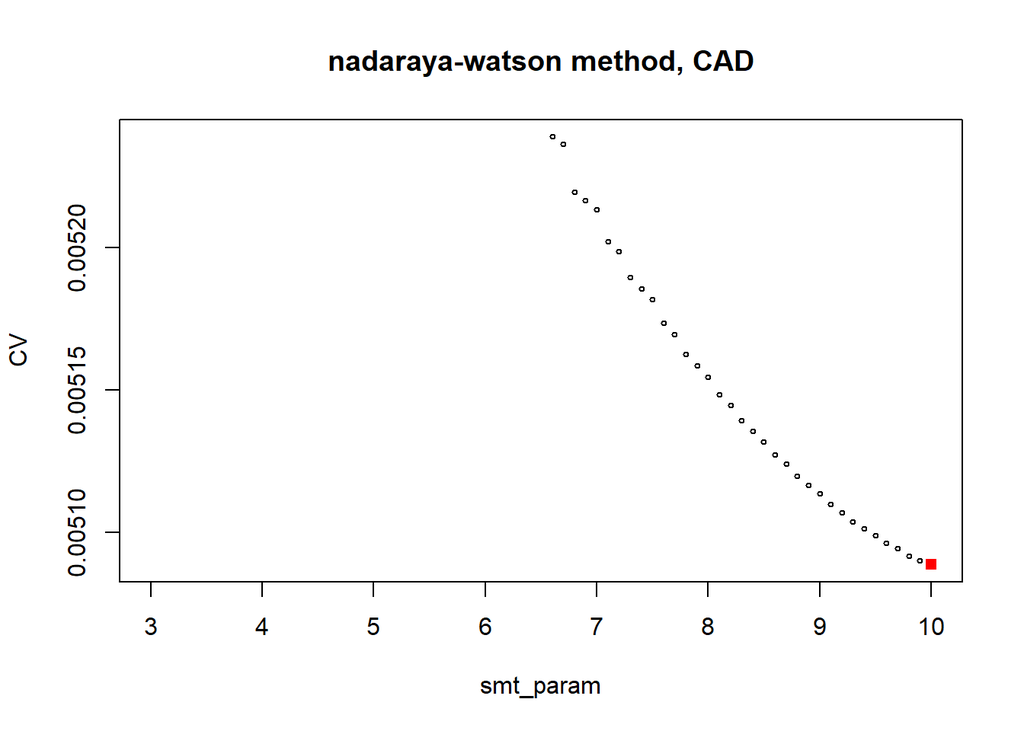

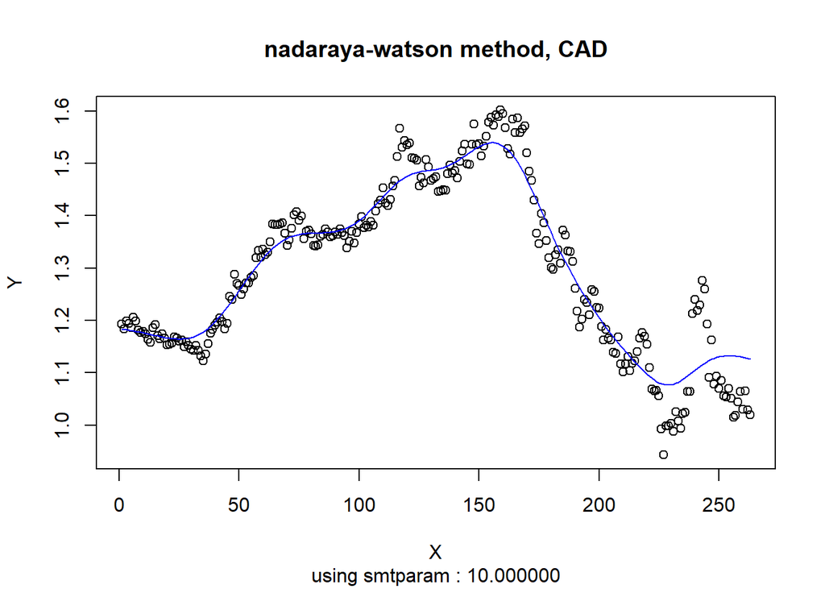

다음은 local linear method를 사용했을 때다. bandwidth로 3~15, 0.1간격으로 사용하도록 하겠다.

```r
pred_err_GBP[2] <- full_test_kfold(estimate_local_linear, data$X, data$GBP, seq(3,15,by = 0.1), k = 10, description = "local linear method, GBF")
```

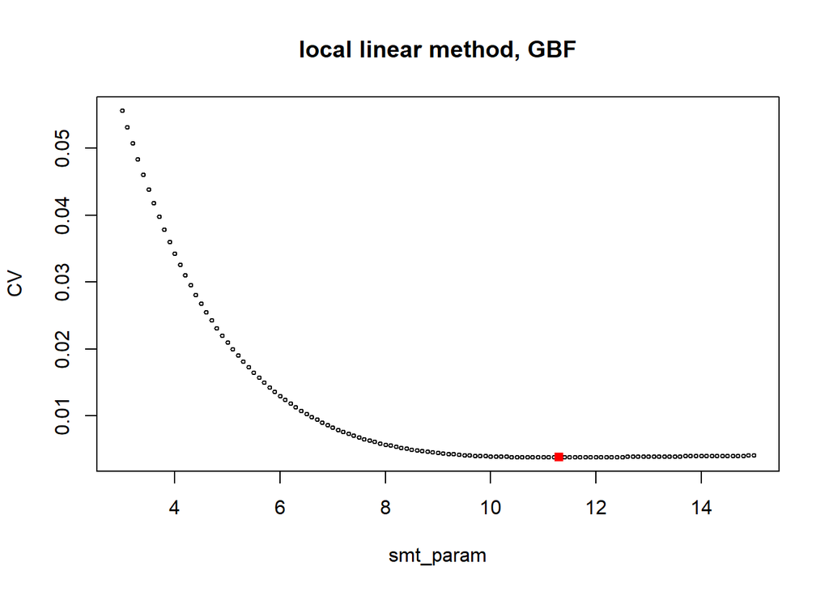

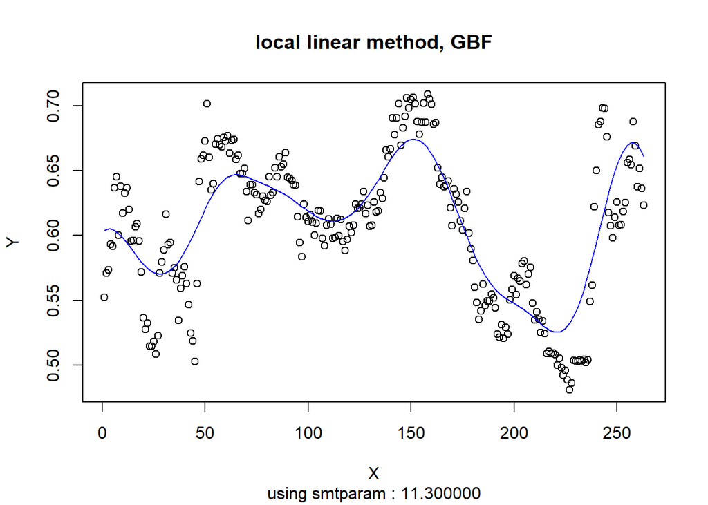

```r
pred_err_CHF[2] <- full_test_kfold(estimate_local_linear, data$X, data$CHF, seq(3,15,by = 0.1), k = 10, description = "local linear method, CHF")
```

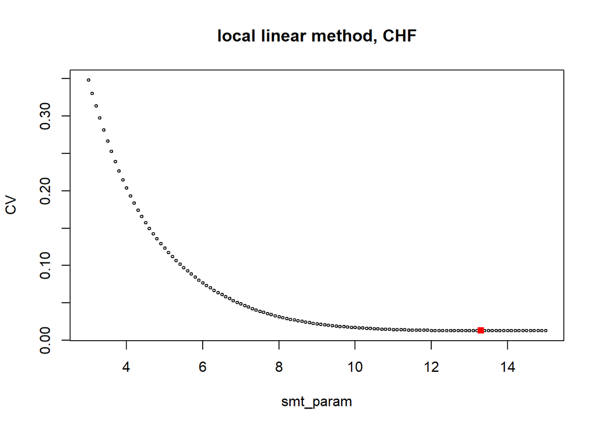

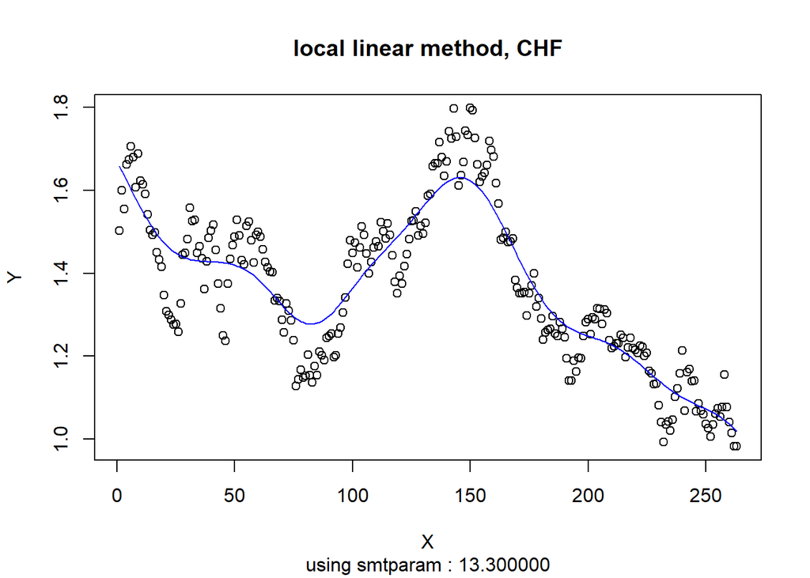

```r
pred_err_CAD[2] <- full_test_kfold(estimate_local_linear, data$X, data$CAD, seq(3,15,by = 0.1), k = 10, description = "local linear method, CAD")
```

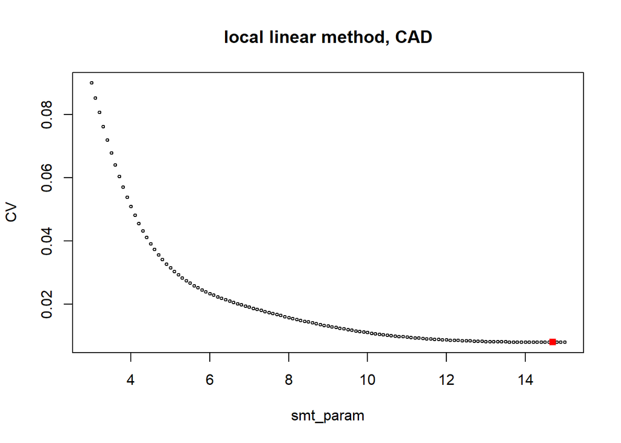

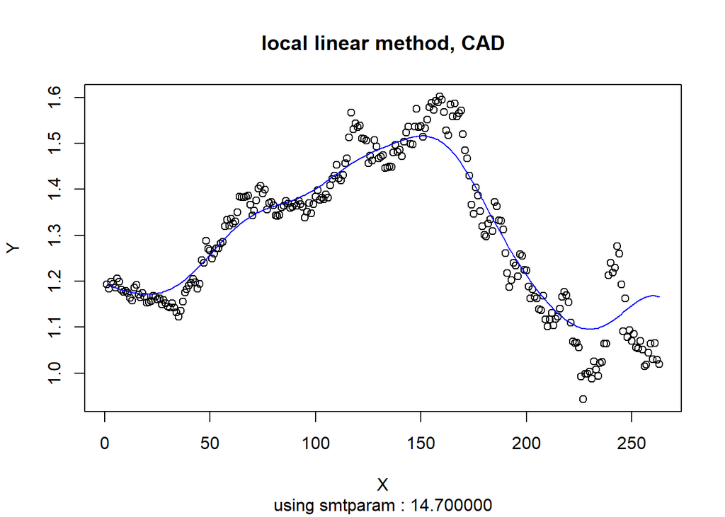

다음은 smoothing spline을 사용했을때다, lambda로 0.000001~0.0003까지 0.000001간격으로 테스트를 해보겠다.

```r
pred_err_GBP[3] <- full_test_kfold(estimate_smoothing_spline, data$X, data$GBP, seq(0.000001,0.0003,by = 0.000001), k = 10, description = "smoothing spline method, GBF")
```

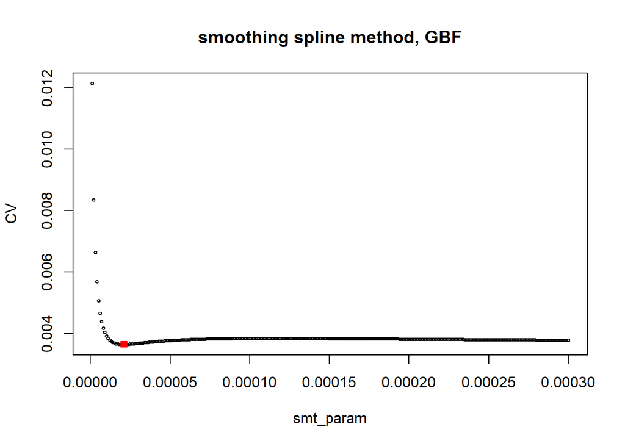

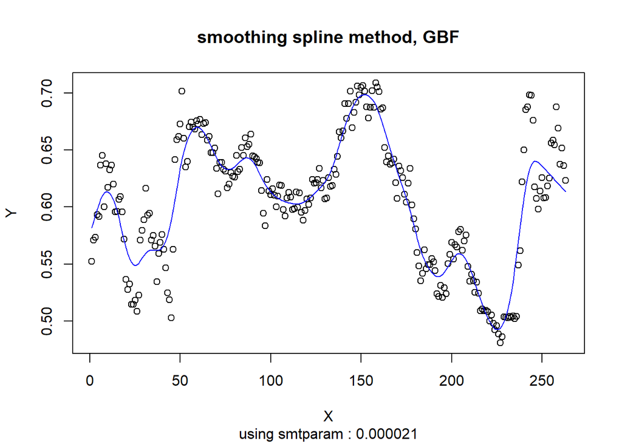

```r
pred_err_CHF[3] <- full_test_kfold(estimate_smoothing_spline, data$X, data$CHF, seq(0.000001,0.0003,by = 0.000001), k = 10, description = "smoothing spline method, CHF")
```

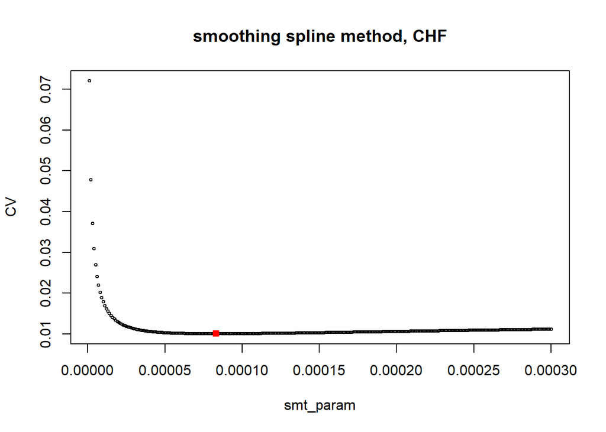

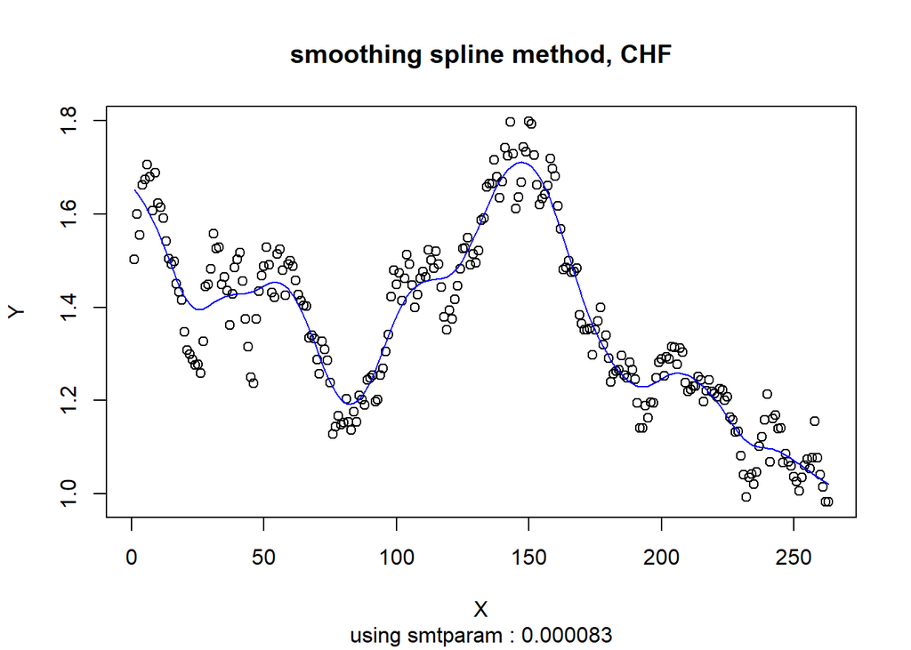

```r
pred_err_CAD[3] <- full_test_kfold(estimate_smoothing_spline, data$X, data$CAD, seq(0.000001,0.0003,by = 0.000001), k = 10, description = "smoothing spline method, CAD")
```

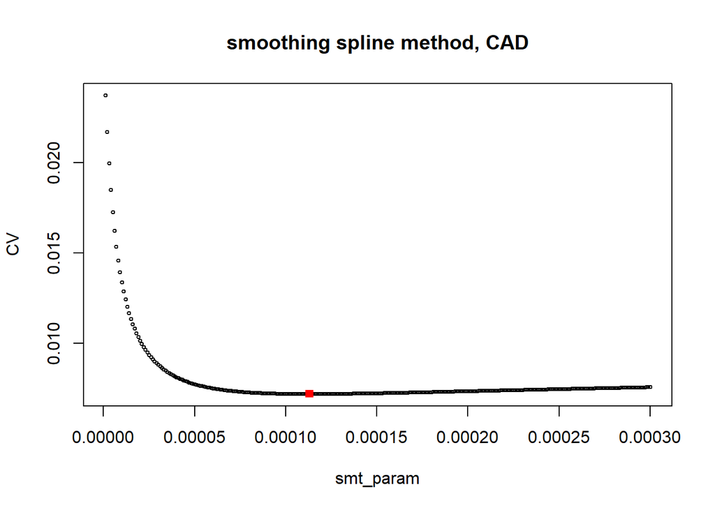

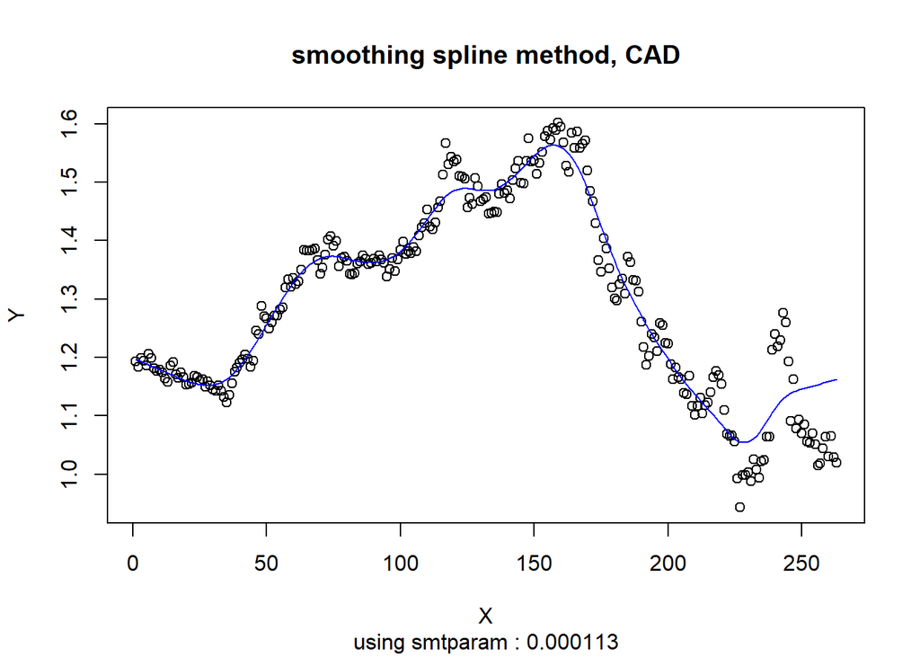

다음은 natural spline (using binomial filter)를 사용했을때다. m으로 2~20까지 2간격으로 테스트를 해보겠다.

```r
pred_err_GBP[4] <- full_test_kfold(estimate_natural_spline_binomfilter, data$X, data$GBP, seq(2,20,by = 2), k = 10, description = "natural spline with binomial filter method, GBF")
```

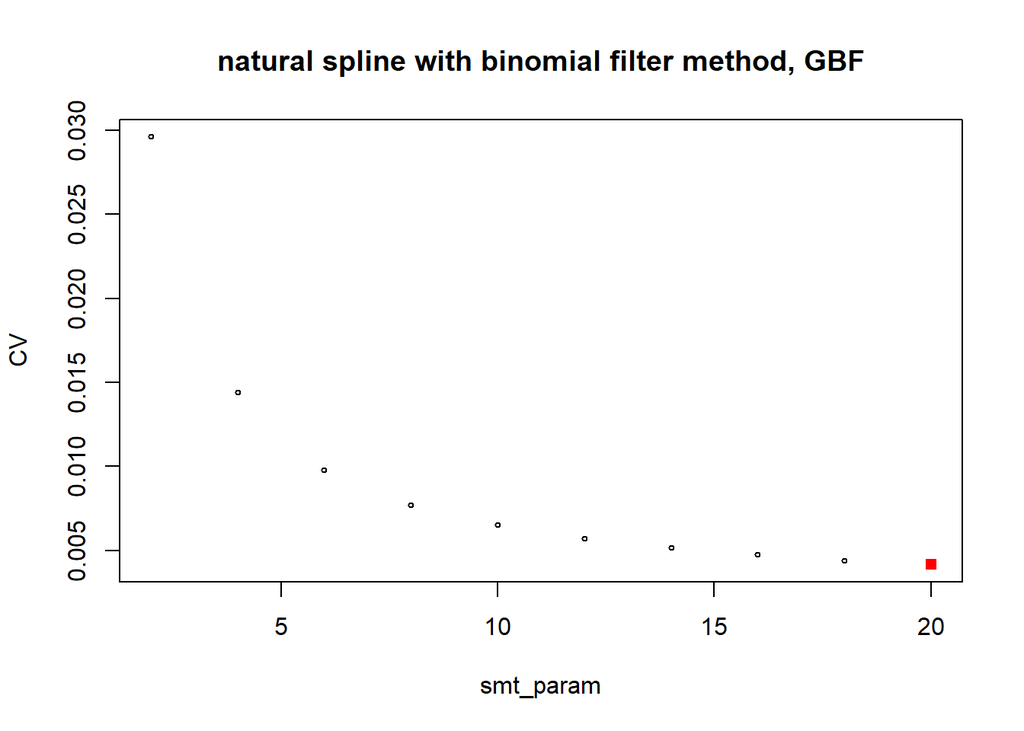

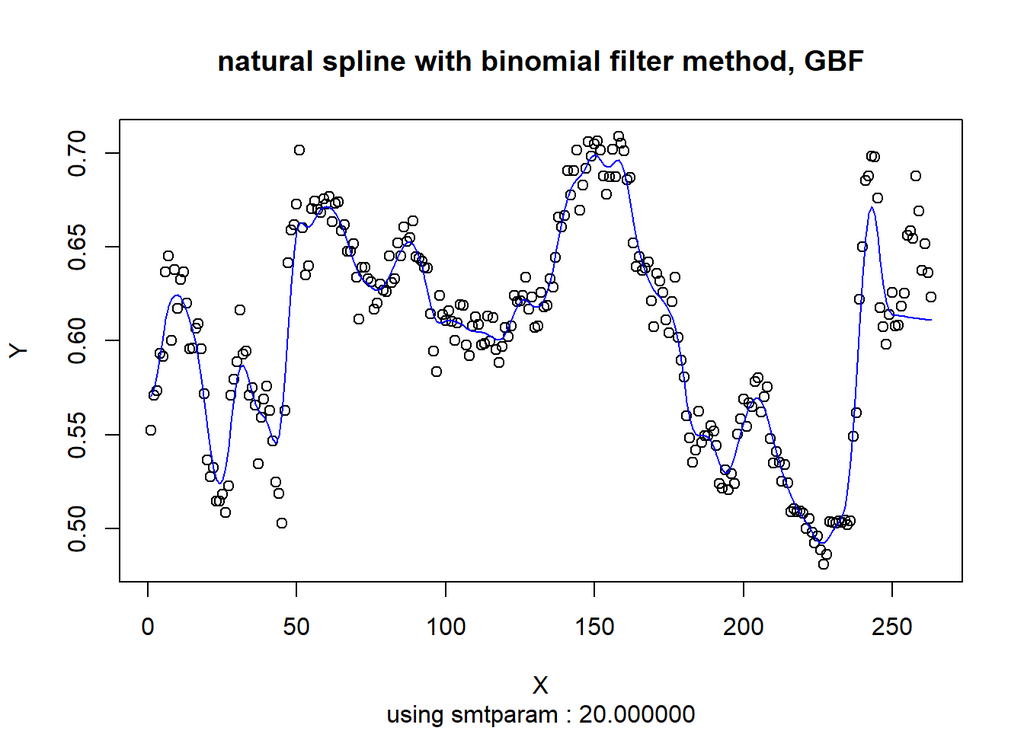

```r
pred_err_CHF[4] <- full_test_kfold(estimate_natural_spline_binomfilter, data$X, data$CHF, seq(2,20,by = 2), k = 10, description = "natural spline with binomial filter method, CHF")
```

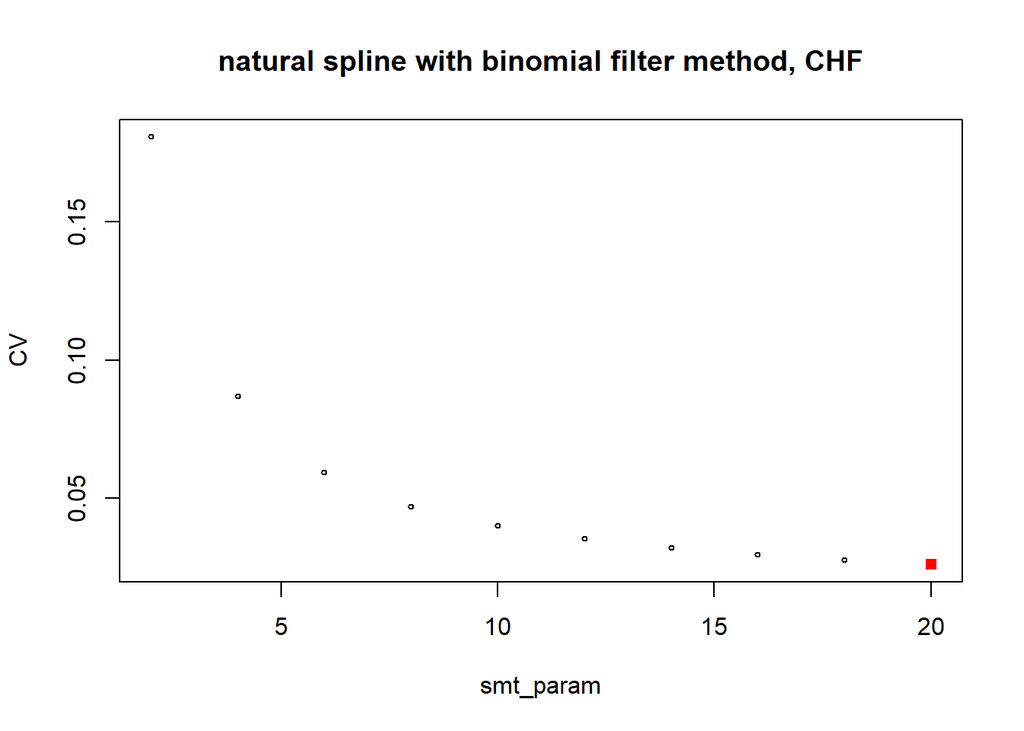

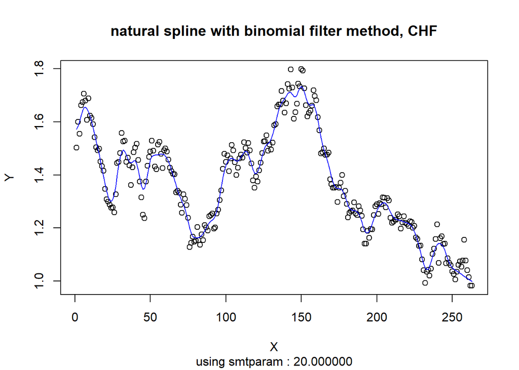

```r
pred_err_CAD[4] <- full_test_kfold(estimate_natural_spline_binomfilter, data$X, data$CAD, seq(2,20,by = 2), k = 10, description = "natural spline with binomial filter method, CAD")
```

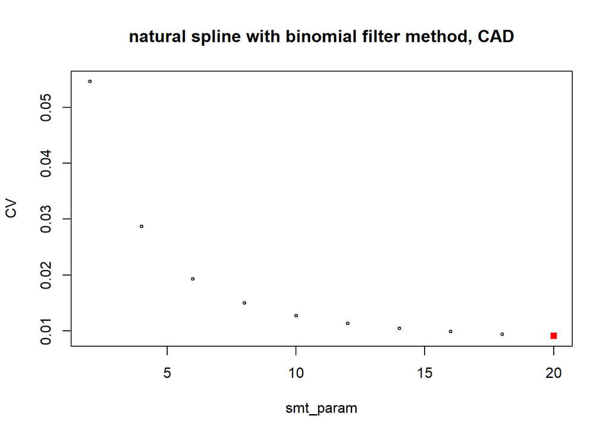

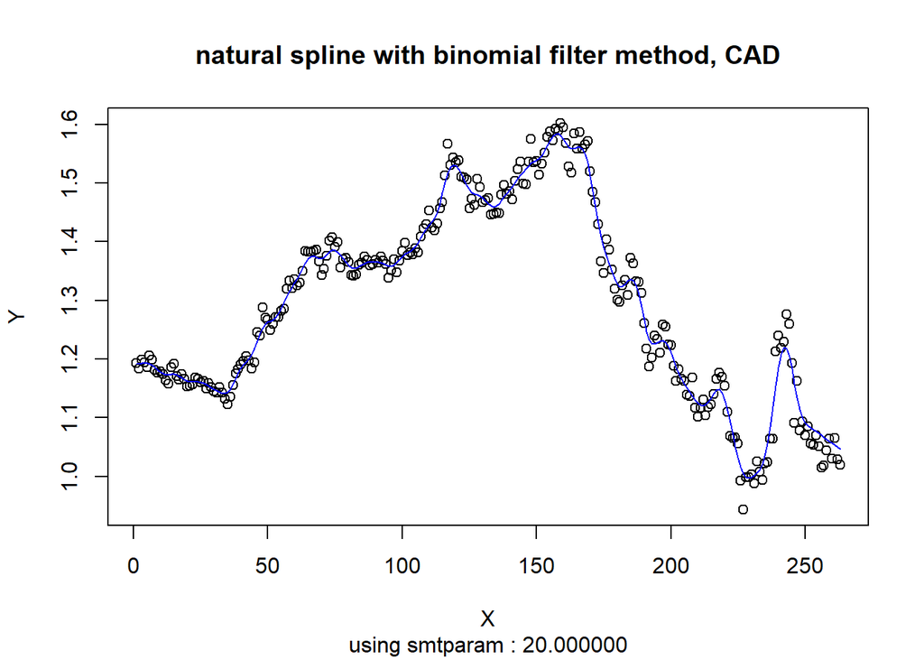

다음은 loess를 사용했을때다. span으로 0.02~0.3까지 0.01간격으로 테스트를 해보겠다.

먼저 linear case이다.

```r
pred_err_GBP[5] <- full_test_kfold(estimate_loess_linear , data$X, data$GBP, seq(0.02,0.3,by = 0.01), k = 10, description = "loess linear method, GBF")
```

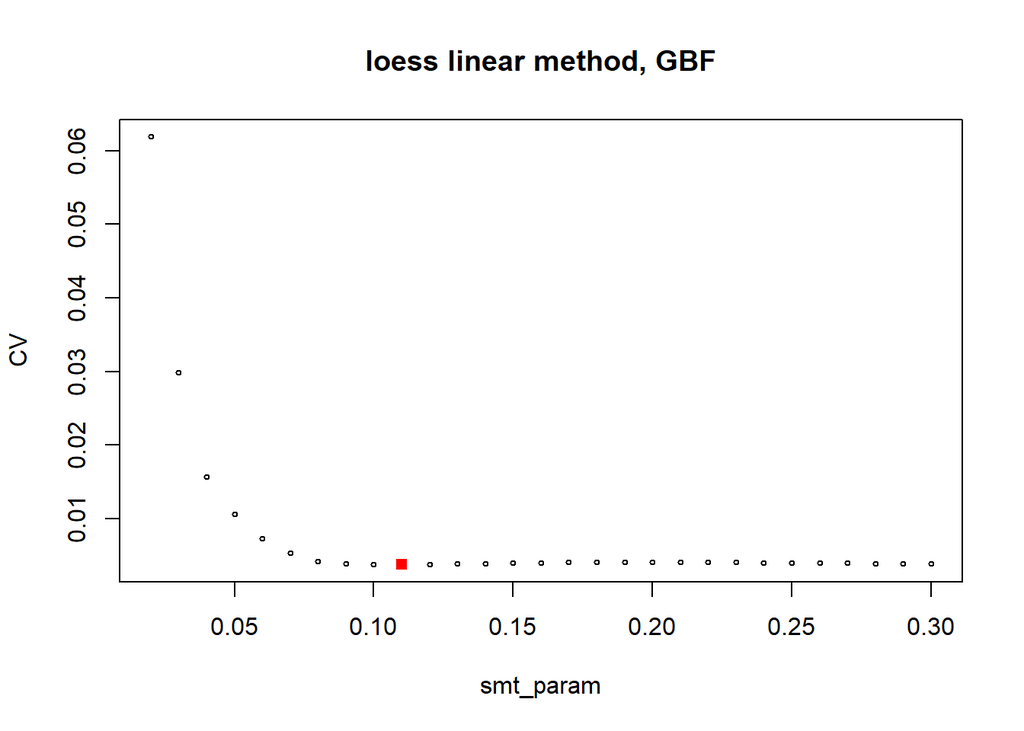

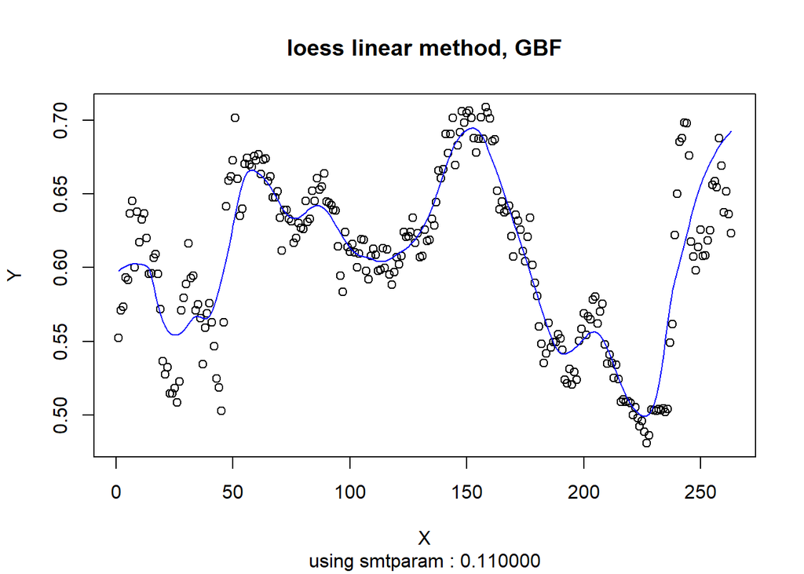

```r
pred_err_CHF[5] <- full_test_kfold(estimate_loess_linear, data$X, data$CHF, seq(0.02,0.3,by = 0.01), k = 10, description = "loess linear method, CHF")
```

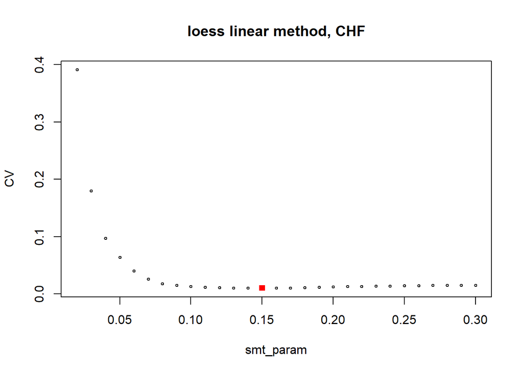

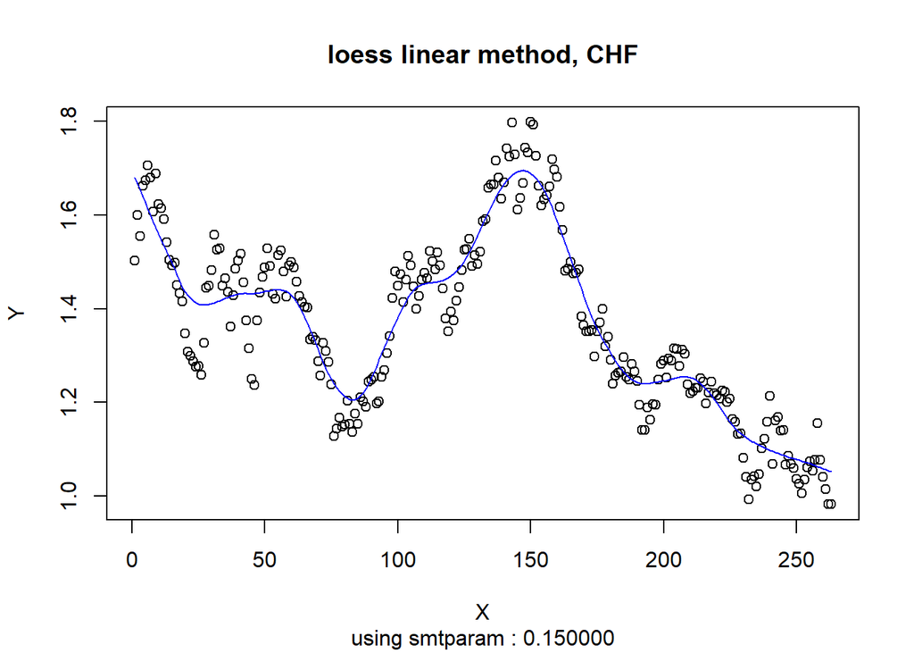

```r
pred_err_CAD[5] <- full_test_kfold(estimate_loess_linear, data$X, data$CAD, seq(0.02,0.3,by = 0.01), k = 10, description = "loess linear method, CAD")
```

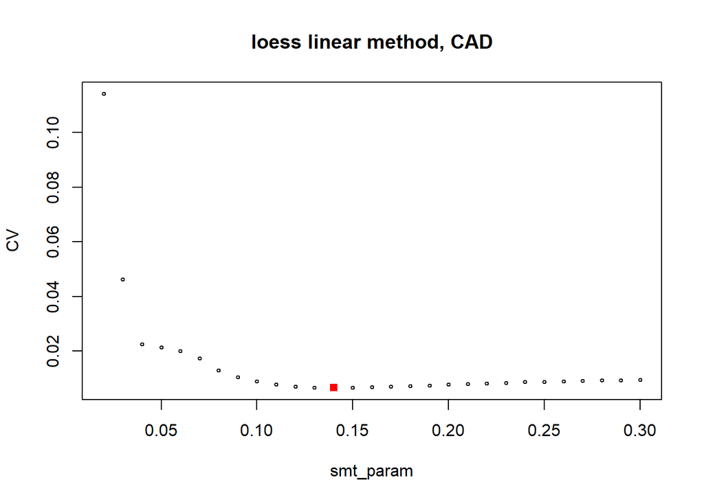

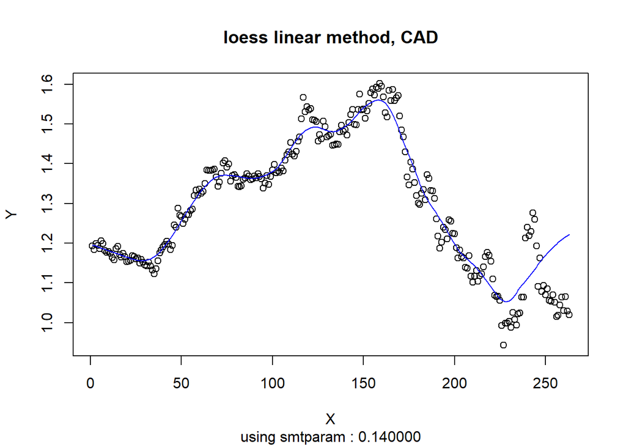

다음은 quadratic case이다. span으로 0.03~0.3까지 0.01간격으로 테스트를 해보겠다.

```r
pred_err_GBP[6] <- full_test_kfold(estimate_loess_quad , data$X, data$GBP, seq(0.03,0.3,by = 0.01), k = 10, description = "loess quadratic method, GBF")
```

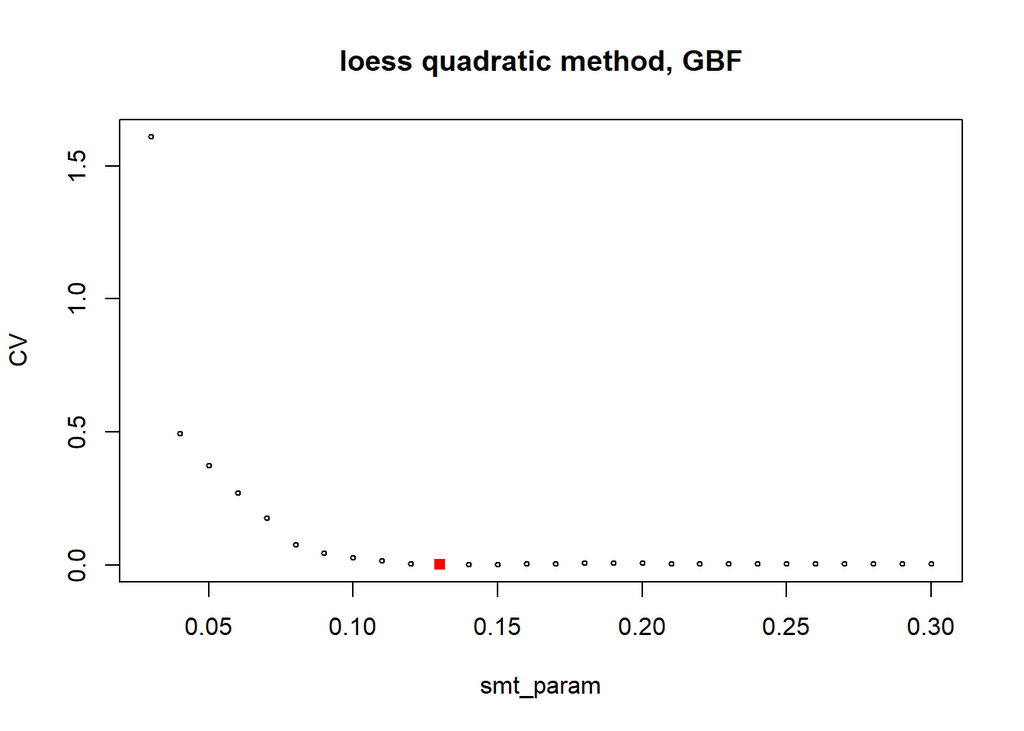

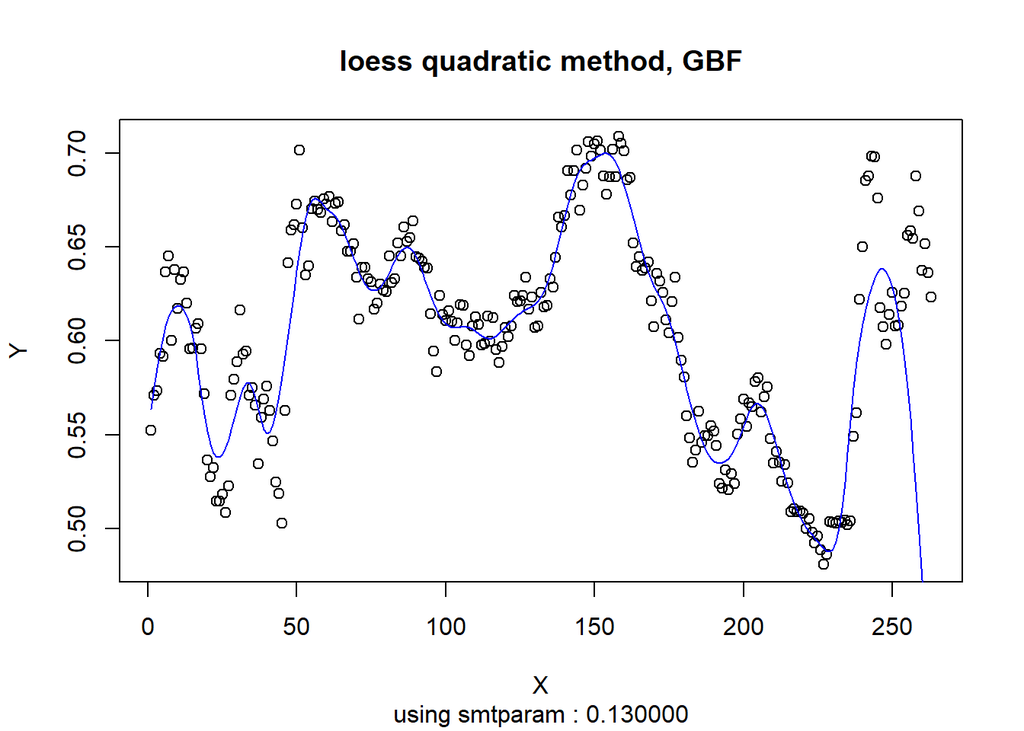

```r
pred_err_CHF[6] <- full_test_kfold(estimate_loess_quad, data$X, data$CHF, seq(0.03,0.3,by = 0.01), k = 10, description = "loess quadratic method, CHF")
```

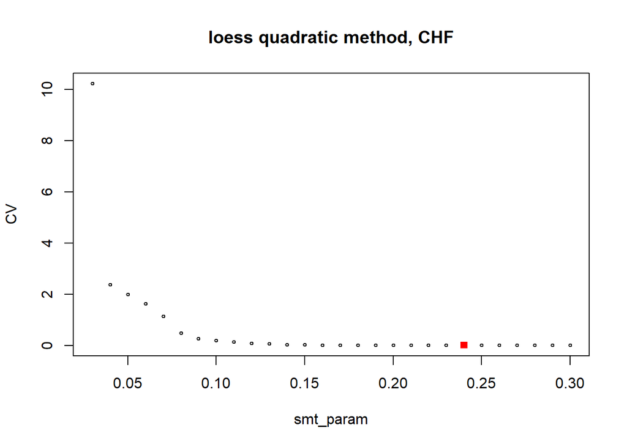

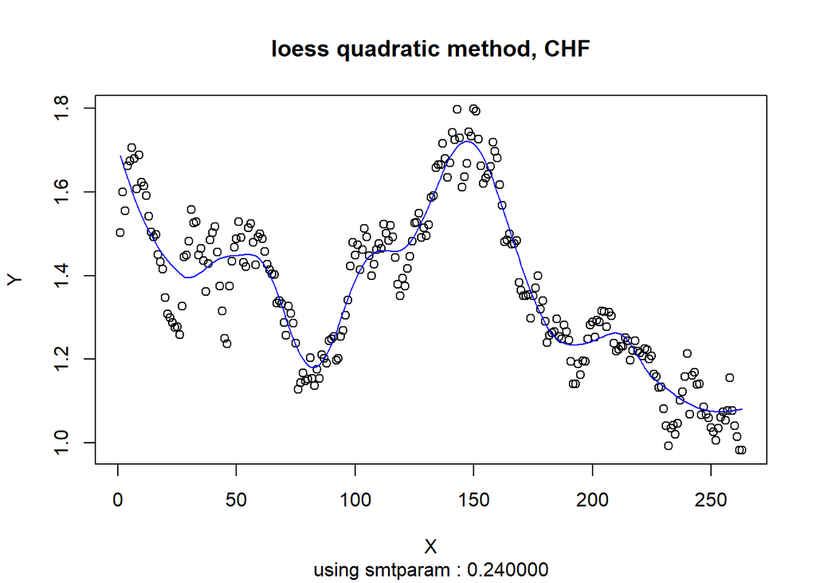

```r
pred_err_CAD[6] <- full_test_kfold(estimate_loess_quad, data$X, data$CAD, seq(0.03,0.3,by = 0.01), k = 10, description = "loess quadratic method, CAD")
```

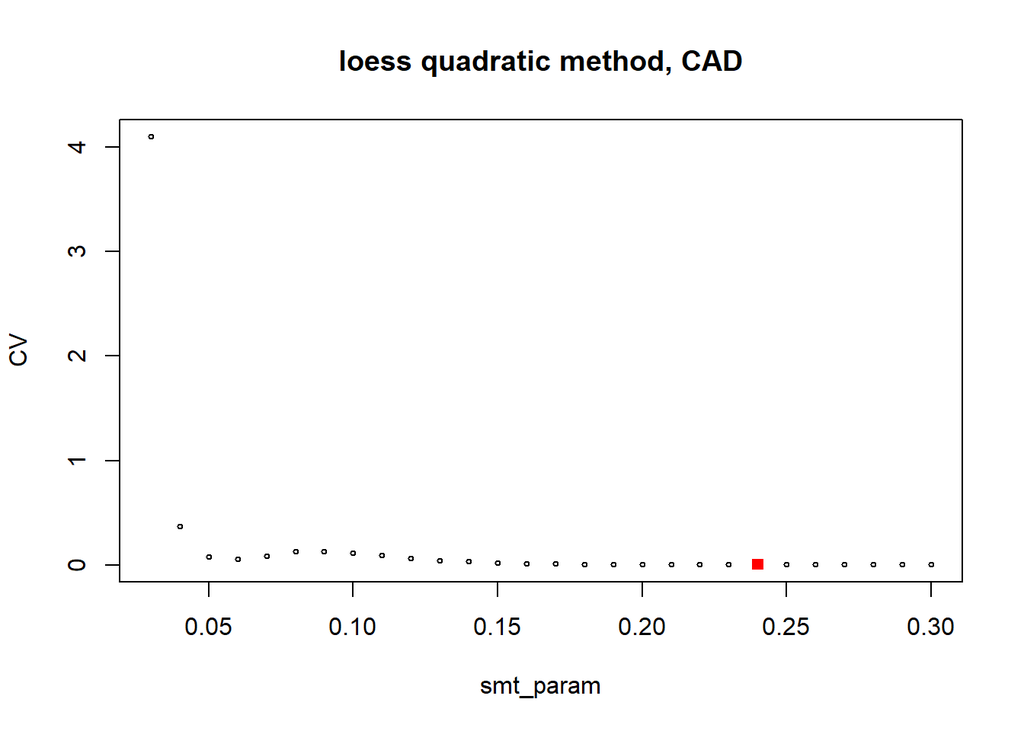

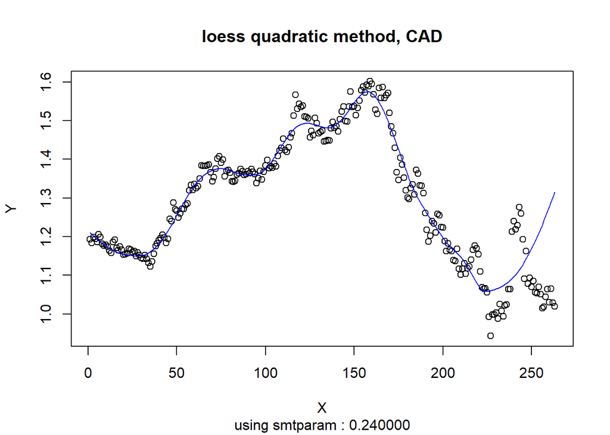

이제, 가장 좋은 method를 찾기위해 앞에서 만든 pred_err 벡터들의 값중 어떤 값이 가장 작은지를 볼것이다.

1 : nadaraya-watson 2 : local polynomial (linear) 3 : smooting spline 4 : natural spline with binomial filter 5 : loess (linear) 6 : loess (quadratic)

```r
which(pred_err_GBP == min(pred_err_GBP, na.rm = TRUE))
```

```
## [1] 1
```

```r
which(pred_err_CHF == min(pred_err_CHF, na.rm = TRUE))
```

[output not shown]

```r
which(pred_err_CAD == min(pred_err_CAD, na.rm = TRUE))
```

[output not shown]

각각 GBP, CHF, CAD에 대해 어떤것이 best method인지를 위와 같이 알아볼 수 있었다.

즉, 10-fold cross validation을 실행했을때, prediction err가 가장 작은 method는 각각 위와 같다는것을 알 수 있었다.